# DIGPD_Preprocessing

SS

09/02/2022

# DIGPD PreProcessing and Normalization

##### Analyst: Samantha Schaffner

##### Date: Aug 25, 2022

The *DIGPD* cohort (n=332 cases and n=190 controls) is a longitudinal study of individuals who developed sporadic PD, with follow-up up to 6 years after diagnosis. All PD cases in the first timepoint have a disease duration of 2 years or less. We are performing this study in collaboration with r. Alexis Elbaz, Dr. Alexis Brice, and Dr. Jean-Christophe Corvol. EPIC arrays were run in Paris, France on bisulfite-converted DNA samples extracted from whole blood. We were provided with idat files for preprocessing and analysis.

The general steps we take, with methods included in this script, are:

Removing outlier samples

Cell type prediction (blood)

Performing normalization using control probes (funnorm)

Removing poor performing probes

Removing variation due to batch effects (ComBat)

### Libraries and outside functions

```r
setwd("~/")
library(sva)
library(Metrics)
library(methylumi)
library(dendextend)
library(locfdr)
library(gplots)
library(lattice)
#library(wateRmelon) #problem with lumi, can't load wateRmelon
library("RColorBrewer")
library(plyr)
library(VennDiagram)
library(ggplot2)
library(qvalue)
library("sva")
library(parallel)
library(gridExtra)
library(grid)
library("reshape2")
library("corrplot")
library(rgr)
library(viridis)
#library(lumi) #can't load
library(missMethyl)
library(hydroGOF)
library(quadprog)
library(genefilter)
library(matrixStats)
library(limma)
library(FlowSorted.Blood.450k)
library(FlowSorted.Blood.EPIC)
library(ewastools)
library(ggrepel)
library(conumee)
library(doParallel)
library(ggplotify)
library(cowplot)
library(ggpubr)
library(tidyverse)

#lumi and wateRmelon functions defined externally
source('~/kobor_shared_coding_resource/lumi_detectOutlier.R')
source('~/kobor_shared_coding_resource/lumi_plotSampleRelation.R')
source('~/kobor_shared_coding_resource/wateRmelon_outlyx.R')
source('~/kobor_shared_coding_resource/wateRmelon_adjustedFunnorm.R')
source('~/kobor_shared_coding_resource/wateRmelon_beadcount.R')

#custom functions
source("~/kobor_shared_coding_resource/PCA_Plot_Function.R")
#source("~/kobor_shared_coding_resource/BadProbe_Function.R")
#source('~/kobor_shared_coding_resource/ECC11.R')
source("~/kobor_shared_coding_resource/correlation_pval.R") #modified slightly so that corr between perfectly confounded variables (PD with dis_duration and age_onset) is 0; also made function verbose
source("~/kobor_shared_coding_resource/heatmap.3_CK.R")
source("~/kobor_shared_coding_resource/Age_Pred_Horvath_NG_SS.R")
```

## Load data and create objects for preprocessing

```r
#read in meta data to get chip IDs for DIGPD
digpd_meta <- read.table("/home1/NEURO/schaffner/preprocessing/digpd_meta_SS.txt", sep="\t")
dim(digpd_meta) #523 patients
idats <- list.files("~/idats")
length(digpd_idats <- idats[substr(idats, 1, 19) %in% digpd_meta$id]) #1046 (2 for each of the 523 samples)

digpd_meta$Basename <- paste(digpd_meta$SentrixBarcode_A, digpd_meta$SentrixPosition_A, sep = "_")
digpd_meta$Chip_Position <- digpd_meta$Basename
digpd_meta$Basename <- file.path("~/idats", digpd_meta$Basename) # Need to have the full pathnames without the ending _Grn.idat or _Red.idat
DIGPD_RG_Raw <- read.metharray(basenames = digpd_meta$Basename, extended = T, force = T)

# Replace samplenames of chip_position to actual sample names:
identical(sampleNames(DIGPD_RG_Raw), digpd_meta$Chip_Position) #TRUE
sampleNames(DIGPD_RG_Raw) <- digpd_meta$Sample_Name
save(DIGPD_RG_Raw, file="~/preprocessing/DIGPD/DIGPD_RG_Raw.RData")

# Creating object to use with ewastools
meth <- read_idats(digpd_meta$Basename)
save(meth, file="~/preprocessing/DIGPD/082022/DIGPD_ewastools_obj_raw.RData")

# Creating MethylSet from RGSet to use with minfi
MSet <- preprocessRaw(DIGPD_RG_Raw)
save(MSet, file="~/preprocessing/DIGPD/082022/DIGPD_MSet_raw.RData")
```

# Sample quality control checks

## ewastools

This check uses the Illumina’s 636 control probes to assess technical parameters including array staining, extension, hybridization, target removal, specificity, and bisulfite conversion.

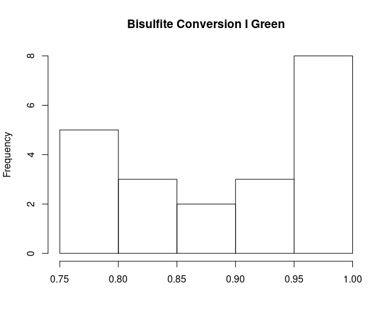

Samples failing type I green bisulfite conversion

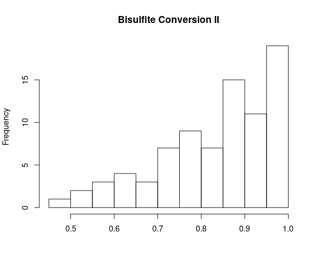

Samples failing type II bisulfite conversion

```r
ctrls = control_metrics(meth)
stripchart(ctrls$`Bisulfite Conversion II`,method="jitter",pch=4,xlab='Bisulfite Conversion II',xlim=c(0,10))
abline(v=1,col=2,lty=3) # can see a group of samples failing here

digpd_meta$failed = sample_failure(ctrls)
table(digpd_meta$failed)
#FALSE  TRUE
#  440    83

#compare this against the outliers removed previously
prev_outliers <- c( "01089GR.visit6",   "01187GZ.visit6",   "01288LC.visit4",   "T-13-2.visitNA",   "T-169-5.visitNA",
"T-17-14.visitNA",  "T-18-1.visitNA",   "T-2-23.visitNA",   "T-216-10.visitNA", "T-22-2.visitNA",
"T-224-10.visitNA", "T-24-1.visitNA",   "T-3-44.visitNA",   "T-30-2.visitNA",   "T-30-33.visitNA",
"T-325-15.visitNA", "T-35-1.visitNA",   "T-356-7.visitNA",  "T-360-19.visitNA", "T-4-9.visitNA",
"T-496-14.visitNA", "T-50-1.visitNA",   "T-50-2.visitNA",   "T-53-2.visitNA",   "T-550-3B.visitNA",
"T-599-13.visitNA", "T-599-18.visitNA", "T-7-7.visitNA",    "T-706-7.visitNA",  "T-711-8.visitNA",
"T-722-43.visitNA", "T-856-13.visitNA", "T-98-1.visitNA",   "01265CD.visit1",   "01158LS.visit6",
"01334CJ.visit4",   "T-415-19.visitNA", "T-819-4.visitNA",  "01264GC.visit1" ) #39 total

new_outliers <- digpd_meta[digpd_meta$failed==TRUE,"Sample_Name"] #83 total
length(new_outliers[new_outliers %in% prev_outliers]) #8

summary(as.factor(digpd_meta[digpd_meta$failed==TRUE,"visite"]))
#   1    4    6 NA's
#  13   24   28   18

visit1NA <- digpd_meta[digpd_meta$failed==TRUE & digpd_meta$visite %in% c(1,NA),"Sample_Name"] #29 samples
length(visit1NA[visit1NA %in% prev_outliers]) #6

#checking individual metrics with the default pass/fail thresholds (reccommended by Illumina)
length(ctrls$Restoration[ctrls$Restoration>0]) #523 (all pass)
length(ctrls$`Staining Green`[ctrls$`Staining Green`>5])  #523 (all pass)
length(ctrls$`Staining Red`[ctrls$`Staining Red`>5])  #523 (all pass)
length(ctrls$`Extension Green`[ctrls$`Extension Green`>5])  #523 (all pass)
length(ctrls$`Extension Red`[ctrls$`Extension Red`>5])  #523 (all pass)
length(ctrls$`Hybridization High/Medium`[ctrls$`Hybridization High/Medium`>1])  #523 (all pass)
length(ctrls$`Hybridization Medium/Low`[ctrls$`Hybridization Medium/Low`>1]) #523
length(ctrls$`Target Removal 1`[ctrls$`Target Removal 1`>1]) #523
length(ctrls$`Target Removal 2`[ctrls$`Target Removal 2`>1]) #523

length(ctrls$`Bisulfite Conversion I Green`[ctrls$`Bisulfite Conversion I Green`>1]) #502 (21 failed)
bisulfite1grn <- ctrls$`Bisulfite Conversion I Green`
names(bisulfite1grn) <- meth$meta$sample_id
hist(ctrls$`Bisulfite Conversion I Green`[ctrls$`Bisulfite Conversion I Green`<1], main="Bisulfite Conversion I Green", xlab=NA)
#all are >0.75, most near 1

length(ctrls$`Bisulfite Conversion I Red`[ctrls$`Bisulfite Conversion I Red`>1]) #523

length(ctrls$`Bisulfite Conversion II`[ctrls$`Bisulfite Conversion II`>1]) #442 (81 failed)
bisulfiteII <- ctrls$`Bisulfite Conversion II`
names(bisulfiteII) <- meth$meta$sample_id
hist(ctrls$`Bisulfite Conversion II`[ctrls$`Bisulfite Conversion II`<1], main="Bisulfite Conversion II", xlab=NA)
#ranging from 0.5-1 with most near 1

#how many fail both metrics?
bisulfite1_fail <- bisulfite1grn[bisulfite1grn<1]
bisulfite2_fail <- bisulfiteII[bisulfiteII<1]

length(dblfail <- names(bisulfite2_fail)[names(bisulfite2_fail) %in% names(bisulfite1_fail)]) #19 (19/21 from bisulfite I also fail bisulfite II)

#failing I and II
table(digpd_meta[digpd_meta$Chip_Position %in% names(bisulfite1_fail),c("PD","men")])
#   men
#PD   0  1
#  0  0  4
#  1  6 11
#most are male PD cases

table(digpd_meta[digpd_meta$Chip_Position %in% names(bisulfite1_fail),c("PD","visite")])
#   visite
#PD  1 4 6
#  0 0 0 0
#  1 1 8 8
#PD cases from visits 4-6 are heavily affected

#checking first timepoint
table(digpd_meta[digpd_meta$Chip_Position %in% names(bisulfite1_fail) & digpd_meta$visite %in% c(1,NA),c("PD","men")])
#   men
#PD  0 1
#  0 0 4
#  1 1 0

#from timepoint 1, 4 male controls and 1 female case (not bad)

#failing II only
table(digpd_meta[digpd_meta$Chip_Position %in% names(bisulfite2_fail)[-which(names(bisulfite2_fail) %in% names(bisulfite1_fail))],c("PD","men")])
#   men
#PD   0  1
#  0  5  9
#  1 26 22

table(digpd_meta[digpd_meta$Chip_Position %in% names(bisulfite2_fail)[-which(names(bisulfite2_fail) %in% names(bisulfite1_fail))],c("PD","visite")])
#   visite
#PD   1  4  6
#  0  0  0  0
#  1 12 16 20

#a lot of PD cases from all timepoints and sexes failed bisulfite II. Retain these since they pass other metrics.

length(ctrls$`Specificity I Green`[ctrls$`Specificity I Green`>1]) #523
length(ctrls$`Specificity I Red`[ctrls$`Specificity I Red`>1]) #523
length(ctrls$`Specificity II`[ctrls$`Specificity II`>1]) #523
length(ctrls$`Non-polymorphic Green`[ctrls$`Non-polymorphic Green`>5]) #523
length(ctrls$`Non-polymorphic Red`[ctrls$`Non-polymorphic Red`>5]) #523
```

## M/U channel intensity

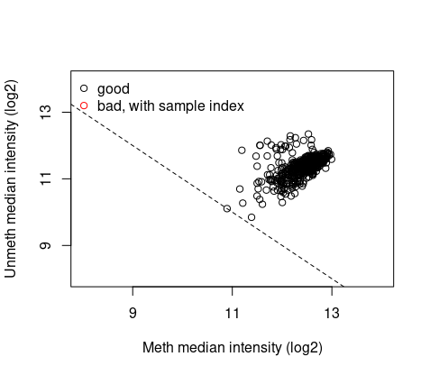

Minfi plotQC

```r
qc <- getQC(MSet)
qc[qc$uMed<10.3 & qc$mMed<11.5,] #these points are near the threshold
#DataFrame with 3 rows and 2 columns
#                            mMed             uMed
#                       <numeric>        <numeric>
#01038BM.visit1  11.2100624832402 10.2714630279044
#01089GR.visit6  11.3864014236408 9.84549005094438
#T-115-1.visitNA 10.8948177633079 10.1059085085712

plotQC(qc)

minfiqc <- c("01038BM.visit1", "01089GR.visit6", "T-115-1.visitNA")
```

# Sex checks

## X chromosome PCA

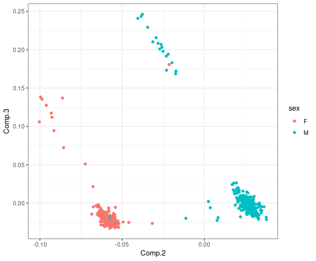

X chromosome PCA

```r
#get the names of X and Y chromosome probes using Kasper Hansen's EPIC annotation
KH_Anno <- read.csv("~/kobor_shared_coding_resource/EPIC_KH_Annotation.csv", row.names = 1)
length(Xprobes <- KH_Anno[KH_Anno$chr=="chrX","Name"]) #19,120
length(Yprobes <- KH_Anno[KH_Anno$chr=="chrY","Name"]) #561

#X chromosome PCA
betas_raw <- getBeta(MSet)
betas_X <- betas_raw[rownames(betas_raw) %in% Xprobes,]
PCA_X <- princomp(betas_X[complete.cases(betas_X),])
X_loadings <- as.data.frame(unclass(PCA_X$loadings))
all.equal(rownames(X_loadings), as.character(digpd_meta$Sample_Name)) #TRUE

X_loadings$sex <- digpd_meta$men
X_loadings$sex <- as.factor(X_loadings$sex)
X_loadings$sex <- gsub(1, "M", gsub(0, "F", X_loadings$sex))
ggplot(X_loadings[,c(1,2,3,ncol(X_loadings))], aes(x=Comp.2, y=Comp.3, col=sex)) + geom_point() + theme_bw()

#reducing males alpha (to see female labelled points that cluster with males)
ggplot(X_loadings[,c(1,2,3,ncol(X_loadings))], aes(x=Comp.2, y=Comp.3, col=sex, alpha=sex)) + theme_bw() + geom_text(label=rownames(X_loadings)) + scale_alpha_manual(values=c(1,0))
#T-50-2.visitNA clusters between M and F (with some M-reported samples)
#T-50-2 was also excluded by Fanny

#reducing females alpha (to see male labelled points that cluster with females)
ggplot(X_loadings[,c(1,2,3,ncol(X_loadings))], aes(x=Comp.2, y=Comp.3, col=sex, alpha=sex)) + theme_bw() + geom_text(label=rownames(X_loadings)) + scale_alpha_manual(values=c(0,1))
#T-410-3.visitNA and 01268BE.visit1 males cluster with females

#Will also look at how funnorm predicts sex (further down)
#When all 3 cohorts were normalized together, only 01268BE.visit1 was predicted as mismatched by funnorm and removed

#collecting potential mismatches for conumee
F_Xchr_check <- rownames(X_loadings[X_loadings$Comp.3>0.01 & X_loadings$Comp.2<(-0.05),]) #11 samples
M_Xchr_check <- rownames(X_loadings[X_loadings$Comp.3>0.15,]) #18 samples
MF_Xchr_check <- rownames(X_loadings[X_loadings$Comp.3<0.05 & X_loadings$Comp.2>(-0.05) & X_loadings$Comp.2<0.01,]) #8 samples

Xchr_check <- unique(c("T-50-2.visitNA", "T-410-3.visitNA", "01268BE.visit1", F_Xchr_check, M_Xchr_check, MF_Xchr_check)) #39 samples in total
bisulfite_fail <- digpd_meta[digpd_meta$Chip_Position %in% dblfail,"Sample_Name"] #sample names for 19 samples failing ewastools
length(Xchr_check[Xchr_check %in% bisulfite_fail]) #only 1 overlap
```

A large number of samples (39) either clustered away from the main M/F centroids or clustered with the wrong sex. The sample IDs were collected for checking with conumee.

## Y chromosome missing values

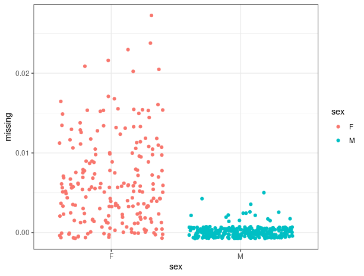

Y chromosome missing values

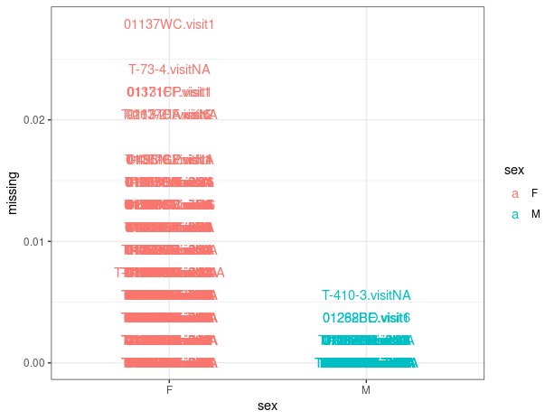

Y chromosome missing values - labelled points

```r
#Y chromosome percent missing values per sample (fewer probes than samples, can't do PCA)
betas_Y <- betas_raw[rownames(betas_raw) %in% Yprobes,]
betas_Y_t <- as.data.frame(t(as.matrix(betas_Y)))
all.equal(rownames(betas_Y_t), as.character(digpd_meta$Sample_Name)) #TRUE
betas_Y_t$missing <- rowSums(is.na(betas_Y_t))/ncol(betas_Y_t)
betas_Y_t$sex <- digpd_meta$men

betas_Y_missing <- betas_Y_t[,c("sex","missing")]
#betas_Y_melt <- melt(betas_Y_missing)
betas_Y_missing$sex <- gsub(0, "F", gsub(1, "M", betas_Y_missing$sex))
ggplot(betas_Y_missing, aes(x=sex, y=missing, col=sex, group=sex)) + geom_jitter() + theme_bw()

#there are a few males with missing Y chromosome values
#collecting missing Y individuals
Ychr_check <- rownames(betas_Y_missing[betas_Y_missing$sex=="M" & betas_Y_missing$missing>0,]) #16 to check
length(Ychr_check[Ychr_check %in% Xchr_check]) #2
length(Ychr_check[Ychr_check %in% bisulfite_fail]) #0

#labelled points
ggplot(betas_Y_missing, aes(x=sex, y=missing, col=sex, group=sex)) + geom_text(label=rownames(betas_Y_missing)) + theme_bw()
```

## Sex prediction with minfi

In this section, we infer the sex of all samples using minfi’s “getSex” function. getSex() works by comparing median total fluorescent intensity of the X chromosome probes and Y-chromosome probes. minfi separates the points by using a default cutoff of -2 for log2med(Y)−log2med(Y), although cutoff can be preferentially specified (use plotSex to get an idea of appropriate cutoffs). NOTE: Males and females should cluster seperately

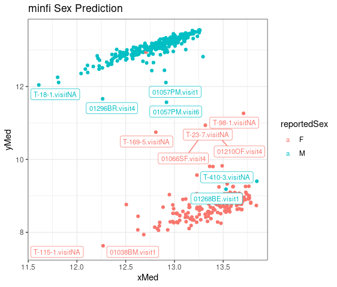

```r
Gset <- mapToGenome(ratioConvert(MSet))
predictedSex <- getSex(Gset, cutoff = -2) #getSex() Estimates samples sex based on methylation data.
#An inconsistency was encountered while determining sex. One possibility is that only one sex is present. We recommend further checks, for example with the plotSex function.
predictedSex_dt <-as.data.frame(predictedSex)
predictedSex_dt$id <- rownames(predictedSex_dt)
colnames(predictedSex_dt)[3] <- "Predicted_Sex"

sex_flagged_ids <- predictedSex_dt[predictedSex_dt$yMed > 10 &  predictedSex_dt$Predicted_Sex=="F" | predictedSex_dt$xMed < 12.5 &  predictedSex_dt$Predicted_Sex=="F" | predictedSex_dt$xMed < 12 &  predictedSex_dt$Predicted_Sex=="M" | predictedSex_dt$yMed < 12 &  predictedSex_dt$Predicted_Sex=="M","id"] #12 flagged

#plotting predicted vs reported
nrow(predictedSex_dt) #523
digpd_meta <- digpd_meta[match(predictedSex_dt$id, digpd_meta$Sample_Name),]
digpd_meta <- cbind(digpd_meta, predictedSex_dt[,1:3])
colnames(digpd_meta)[3] <- "reportedSex"
digpd_meta$reportedSex <- gsub(0, "F", gsub(1, "M", digpd_meta$reportedSex))
table(digpd_meta$Predicted_Sex, digpd_meta$reportedSex)
#      F   M
#  F 205   2
#  M   1 315

#3 mismatches
digpd_meta[digpd_meta$Predicted_Sex!=digpd_meta$reportedSex,"Sample_Name"] #01268BE.visit1  T-410-3.visitNA T-50-2.visitNA

ggplot(digpd_meta, aes(x=xMed, y=yMed, col=reportedSex)) + geom_point() + theme_bw() + ggtitle("minfi Sex Prediction") + geom_label_repel(data = digpd_meta %>%
                     dplyr::filter(yMed > 10 &  reportedSex=="F" | yMed < 12.5 & reportedSex=="M" | xMed < 12.5), aes(label = Sample_Name), size = 3, nudge_y = -0.1)

digpd_meta$flag <- NA
digpd_meta[digpd_meta$Sample_Name %in% sex_flagged_ids,"flag"] <- "Far from XY cluster centroid"
digpd_meta[digpd_meta$Sample_Name %in% c("01268BE.visit1",  "T-410-3.visitNA", "T-50-2.visitNA"),"flag"] <- "Predicted/reported sex mismatch"


#visual check of samples far from centroid
ggplot(digpd_meta, aes(x=xMed, y=yMed, col=flag)) + geom_point() + theme_bw() + ggtitle("minfi Sex Prediction") + theme(legend.position = "none")

minfi_check <- digpd_meta[complete.cases(digpd_meta$flag),"Sample_Name"] #15 to check
```

Quite a few samples cluster away from centroids, and 3 are mismatched.

## Using CNVs to examine sex-flagged samples

To further investigate the samples failing sex QC, we used CNV profiles to identify sex based on X and Y chromosomal copy number variations in the respective samples. For this analysis, we used the conumee R package that performs CNV analysis using Illumina 450k or EPIC DNA methylation arrays. CNV analysis is performed by normalizing the combined intensity values of both ‘methylated’ and ‘unmethylated’ channel of each CpG using a set of normal controls (i.e. with a flat genome, not showing any copy-number alterations).

Code from Rebecca Asiimwe.

#### Preparing data sets

We want to choose a subset of controls (Rebecca did 50 for 17 samples) to compare samples to, since conumee is time intensive and produces an individual comparison plot for every control.

```r
#collecting samples to check
length(Xchr_check) #39
length(Ychr_check) #16
length(minfi_check) #15
length(conumee_ids <- unique(c(Xchr_check, Ychr_check, as.character(minfi_check)))) #61 (!)

#Subsetting dataset to exclude sex mismatched samples and samples failing control probe checks, and selecting only males as our controls
controls <- digpd_meta[-which(digpd_meta$Sample_Name %in% conumee_ids|digpd_meta$Sample_Name %in% bisulfite1_fail),]
controls_filtered <- controls[controls$reportedSex=="M",]
controls_filtered <- controls_filtered[1:70,] #selecting 70 controls for 68 cases

#Creating one metadata object with selected controls and sex mismatched samples
meta_sex_mismatch_control <- rbind(controls_filtered, digpd_meta[digpd_meta$Sample_Name %in% conumee_ids,])
rownames(meta_sex_mismatch_control) <- meta_sex_mismatch_control$Sample_Name

#Filtering RGset to select control samples
RGset_subset <- DIGPD_RG_Raw[, sampleNames(DIGPD_RG_Raw) %in% meta_sex_mismatch_control$Sample_Name]
dim(RGset_subset) #1051943     131

#Matching sample names in control metadata with filtered RGset
all(colnames(RGset_subset) %in% rownames(meta_sex_mismatch_control)) #TRUE
meta_sex_mismatch_control <- meta_sex_mismatch_control[match(colnames(RGset_subset), rownames(meta_sex_mismatch_control)),]
identical(colnames(RGset_subset), rownames(meta_sex_mismatch_control)) #TRUE

#Creating an mset object required to run conumee
mset_conumee <- preprocessIllumina(RGset_subset)
```

#### Identifying conumee controls and CNV calling

```r
#Conumee annotation
anno <- CNV.create_anno(array_type="EPIC", chrXY=TRUE, bin_minprobes=15, bin_minsize=50000)
anno #863904 probes
mranges_cnv <- mapToGenome(mset_conumee)
anno@probes <- subsetByOverlaps(anno@probes, granges(mranges_cnv)) # method to subset S4 object (anno)
anno #862927 probes
annoProbes <- as.data.frame(anno@probes)
mset_conumee <- mset_conumee[which(rownames(mset_conumee) %in% rownames(annoProbes)), ]
dim(mset_conumee) #862927 probes

#Identify Conumee Controls
#Telling conumee which samples in our data and metadata objects are our “karyotypically normal” control samples for comparison to.
all.equal(colnames(mset_conumee), as.character(meta_sex_mismatch_control$Sample_Name)) # must be TRUE

#Specifying which samples will be used as CNV controls
meta_sex_mismatch_control$Status <- NA
meta_sex_mismatch_control[meta_sex_mismatch_control$Sample_Name %in% conumee_ids,"Status"] <- "MISMATCH"
meta_sex_mismatch_control[-which(meta_sex_mismatch_control$Sample_Name %in% conumee_ids),"Status"] <- "CONTROL"
summary(as.factor(meta_sex_mismatch_control$Status))
# CONTROL MISMATCH
#      70       61

cnv_controls <-  meta_sex_mismatch_control$Status == "CONTROL"
cnv_controls

#Parallel CNV Calling
#Load into cnv calling format
cnv_input <- CNV.load(mset_conumee) #intensities are abnormally low (< 5000).

#Parallelizing the CNV calling so that multiple samples are called at once
#Initialize cluster
cl <- makeCluster(24)
registerDoParallel(cl)

#Parallel cnv fit
cnv_calls <- foreach (i =  1:ncol(mset_conumee),
                      .export = c("CNV.fit", "CNV.bin", "CNV.segment")) %dopar%
  CNV.segment(
    CNV.bin(
      CNV.fit(
        cnv_input[i], ref = cnv_input[cnv_controls], anno = anno)))

#Kill cluster
stopCluster(cl)

names(cnv_calls)
names(cnv_calls) <- meta_sex_mismatch_control$Sample_Name
```

#### Samples flagged as mismatches or those far from cluster centroids

```r
#Recall of samples flagged as ar from cluster centroids
meta_sex_mismatch_control[meta_sex_mismatch_control$Status=="MISMATCH","Sample_Name"]
```

#### CNV plots

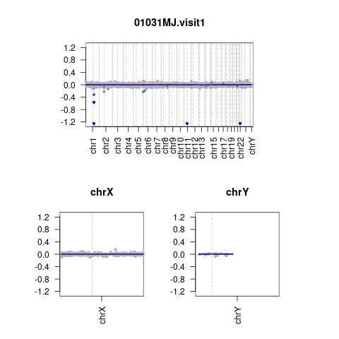

Example of normal male in conumee

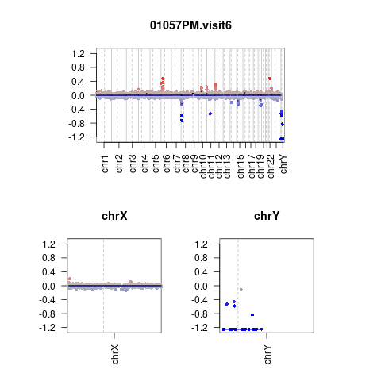

Example of inconclusive sex in conumee

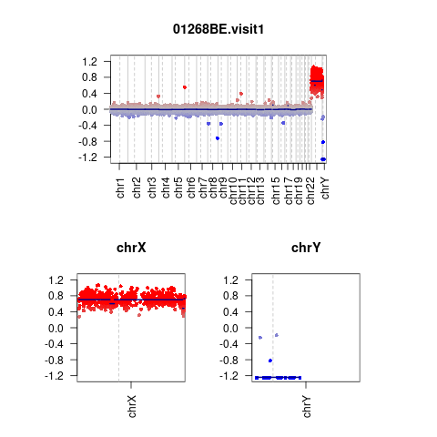

Example of sex-mismatched sample (male self-report, female in minfi & conumee)

```r
#Function to loop through cnv_calls object and plot all samples (controls and mismatches)
for(i in names(cnv_calls)){

  p1 <- as.grob(~CNV.genomeplot(cnv_calls[[i]], chr = "all", chrX = TRUE, chrY = TRUE,
                                centromere = TRUE, detail = TRUE, main = i,
                                ylim = c(-1.25, 1.25), set_par = TRUE, cols = c("blue", "blue","gray", "red", "red")))
  #chrX
  p2 <- as.grob(~CNV.genomeplot(cnv_calls[[i]], chr = "chrX",
                                centromere = TRUE, detail = TRUE, main = "chrX",
                                ylim = c(-1.25, 1.25), set_par = TRUE, cols = c("blue", "blue","gray", "red", "red")))
  #chrY
  p3 <- as.grob(~CNV.genomeplot(cnv_calls[[i]], chr = "chrY",
                                centromere = TRUE, detail = TRUE, main = "chrY",
                                ylim = c(-1.25, 1.25), set_par = TRUE, cols = c("blue", "blue","gray", "red", "red")))

  grid1 <- plot_grid(p1, nrow = 1, ncol = 1, scale = c(.8))
  merged_grids <- plot_grid(p2, p3, nrow = 1, ncol = 2, scale = c(.8))
  plot <- plot_grid(grid1, merged_grids, nrow = 2, ncol = 1, align = "h", scale = c(.8))

  sample_id <- paste0("# ", i)
  sample_id <- noquote(sample_id)
  print(sample_id)

  if(i %in% conumee_ids){ lab="FLAG_" } else { lab = "" }

  png(paste("~/preprocessing/DIGPD/082022/conumee/", lab, i, ".png", sep=""))
  print(plot)
  dev.off()

}

#examined resulting plots and recorded likely sex via CNV profiles
#reading in conumee results and adding to metadata
conumee <- read.csv("~/preprocessing/DIGPD/082022/conumee/DIGPD_conumee.csv", stringsAsFactors=FALSE)
all(conumee$ID %in% digpd_meta$Sample_Name) #FALSE
conumee$ID[-which(conumee$ID %in% digpd_meta$Sample_Name)] #T-121.1.visitNA  T-224-10-visitNA
#fix typos in names
conumee$ID[conumee$ID=="T-121.1.visitNA"] <- "T-121-1.visitNA"
conumee$ID[conumee$ID=="T-224-10-visitNA"] <- "T-224-10.visitNA"
all(conumee$ID %in% digpd_meta$Sample_Name) #TRUE

meta_sub1 <- digpd_meta[digpd_meta$Sample_Name %in% conumee$ID,]
meta_sub1 <- meta_sub1[match(conumee$ID, meta_sub1$Sample_Name),]
all(meta_sub1$Sample_Name==conumee$ID) #TRUE
meta_sub1$conumeeSex <- conumee$conumee

meta_sub2 <- digpd_meta[-which(digpd_meta$Sample_Name %in% conumee$ID),]
meta_sub2$conumeeSex <- NA

digpd_meta <- rbind(meta_sub1, meta_sub2)
rm(meta_sub1, meta_sub2)

digpd_meta[-which(digpd_meta$reportedSex==digpd_meta$Predicted_Sex),c("Sample_Name","reportedSex","Predicted_Sex","conumeeSex")]
#        Sample_Name reportedSex Predicted_Sex conumeeSex
#236  01268BE.visit1           M             F          F
#433 T-410-3.visitNA           M             F          F
#450  T-50-2.visitNA           F             M          M
#conumee and minfi agree, suggesting mis-labeling. To remove those samples.

conumee_meta <- digpd_meta[complete.cases(digpd_meta$conumeeSex),]
#disagreement between reported and conumee
conumee_meta[-which(conumee_meta$reportedSex==conumee_meta$conumeeSex),c("Sample_Name","reportedSex","Predicted_Sex","conumeeSex")] #the 3 mismatched samples identified above + inconclusives.
#        Sample_Name reportedSex Predicted_Sex   conumeeSex
#37   01057PM.visit6           M             M inconclusive
#177  01194LY.visit1           M             M inconclusive
#236  01268BE.visit1           M             F            F
#258  01296BR.visit4           M             M inconclusive
#372  T-18-1.visitNA           M             M inconclusive
#433 T-410-3.visitNA           M             F            F
#450  T-50-2.visitNA           F             M            M

#disagreement between predicted and conumee
conumee_meta[-which(conumee_meta$Predicted_Sex==conumee_meta$conumeeSex),c("Sample_Name","reportedSex","Predicted_Sex","conumeeSex")] #the 4 "inconclusives" identified above.

sex_mismatch <- conumee_meta[-which(conumee_meta$reportedSex==conumee_meta$conumeeSex),c("Sample_Name","reportedSex","Predicted_Sex","conumeeSex")]

#save for later
save(sex_mismatch, bisulfite_fail, minfiqc, digpd_meta, file="~/preprocessing/DIGPD/082022/DIGPD_sexchecked_objs.RData")
#write.csv(sex_mismatch, file="~/preprocessing/DIGPD/082022/conumee/sex_mismatches.csv", row.names=F)
#write.csv(digpd_meta, file="~/preprocessing/DIGPD/082022/digpd_meta_conumee.csv", row.names=F)
```

### Samples flagged for removal

CNV analysis was able to confirm sex for the majority of individuals who clustered away from centroids. Individuals with a mismatch between predicted and reported sex, or with inconclusive sex will be removed:

01057PM.visit6

01194LY.visit1

01268BE.visit1

01296BR.visit4

T-18-1.visitNA

T-410-3.visitNA

T-50-2.visitNA

## SNP Control Probes Sample Clustering

There are 59 control probes which measure single nucleotide polymorphisms which we use for quality control. These are stored in their own slot in the RGChannelSet object, so they don’t need to be filtered out since we will use getBeta() to later pull out the information for non-SNP probes only. The SNP probe beta values can be pulled separately using getSnpBeta() for QC checks.

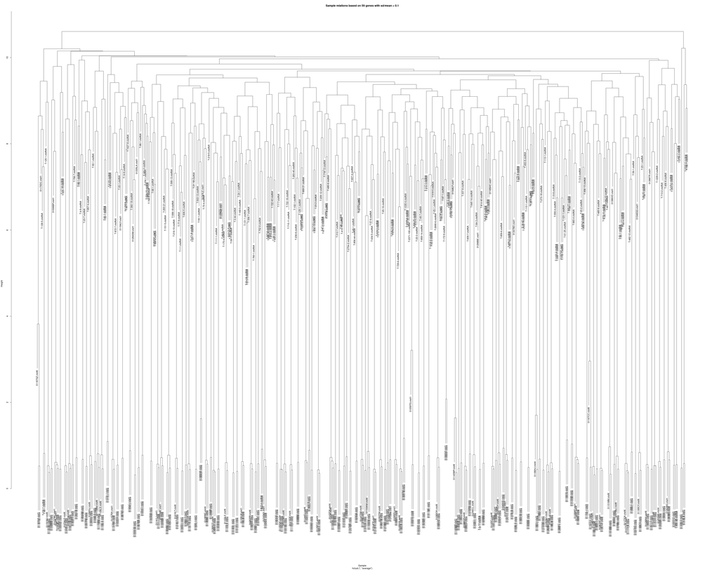

SNP probe clustering: all samples

```r
length(locusNames <- getManifestInfo(DIGPD_RG_Raw, "locusNames")) # Gets all probe names
#865,859 probes are in the RGChannelSet
#this corresponds to the total number of probes when 977 probes were removed from EPIC manifest B3
#this excludes the 59 SNP control probes

#getSnpInfo() provides the columns with rs, maf info for each probe/CpG on the array
#getSnpBeta() provides the DNAm values for the 59 SNP control probes
rs.probes <- getSnpBeta(DIGPD_RG_Raw)
plotSampleRelation(rs.probes,cex=1,method="cluster")

#individuals cluster together
```

As expected, individuals sampled in multiple time points cluster together.

## Contamination check

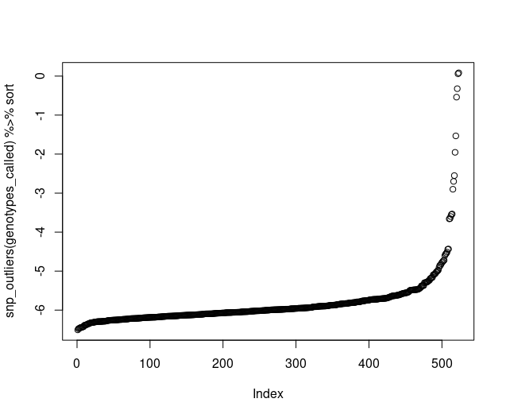

```r
# While ewastools implements the LOESS normalization (Heiss and Brenner, 2015), the developers of the package says not use the normalization "as it does little to protect against batch effects but can result in the removal of genuine biological signal". They recommended to adjust for relevant technical covariates in regression models later.

#use ewastools object
beta <- dont_normalize(meth)

#pulling out the SNP probes
snps <- meth$manifest[probe_type=="rs",index]
snps <- beta[snps,]

# These SNPs are then used as input for call_genotypes(). This function estimates the parameters of a mixture model consisting of three Beta distributions representing the heterozygous and the two homozygous genotypes, and a fourth component, a uniform distribution, representing outliers. The functions returns posterior probabilities used for soft classification.
#In simple words, we are determining the probability for every SNP whether they belong to 1 of 4 distributions, 3 of which correspond to the 3 expected genotypes (AA, AB, BB), and the 4th distribution corresponds to outside / in-between these expected genotype distributions. SNPs with a higher probability of belonging to this 4th distribution indicate mixing between more than one genotype

genotypes_called <- call_genotypes(snps,learn=T)

# fit mixture model to call genotypes
snps_called <- call_genotypes(snps, learn = T)

# call genotype clusters
digpd_meta <- digpd_meta %>% mutate(genotype_cluster = as.factor(enumerate_sample_donors(genotypes_called)))

# examine probability outlier
plot(snp_outliers(genotypes_called) %>% sort)
digpd_meta$outlier = snp_outliers(genotypes_called)
SNPoutliers <- digpd_meta[digpd_meta$outlier > -4,"Sample_Name"] #14 SNP outliers
# [1] T-30-2.visitNA   T-496-14.visitNA 01010GM.visit1   01027KG.visit1   01082PP.visit1   01140WP.visit4   01141LJ.visit6   01155KM.visit4   01354GM.visit4
#[10] 01375SC.visit4   T-191-2.visitNA  T-209-12.visitNA T-358-25.visitNA T-796-7.visitNA
```

14 samples were flagged for potential contamination.

## Detection p-value (minfi)

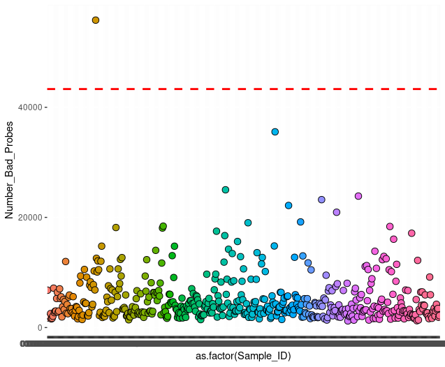

```r
#1e-16 threshold
detP <- detectionP.minfi(DIGPD_RG_Raw)
probe_num <- round(nrow(detP)*0.05)
badDetP <- detP>=0.01
avgPval <- as.data.frame(colSums(badDetP))
avgPval$Sample <- rownames(avgPval)
colnames(avgPval) <- c("Number_Bad_Probes", "Sample_ID")
(badSamps <- avgPval$Sample_ID[avgPval$Number_Bad_Probes>=probe_num]) #"01089GR.visit6"
length(badSamps) #1

# Visualization of outlier samples
ggplot(avgPval)+
  geom_point(aes(as.factor(Sample_ID), Number_Bad_Probes, fill=Sample_ID), shape=21, size=3)+
  geom_hline(yintercept = probe_num, linetype = "dashed", color = "red", size = 1)+
  theme(legend.position = "none")
```

## Bead count Every probe has multiple beads which serves as replicate readings/multiple measurements per sample. If a given sample has fewer than 3 beads/reads that value is given an NA(missing).

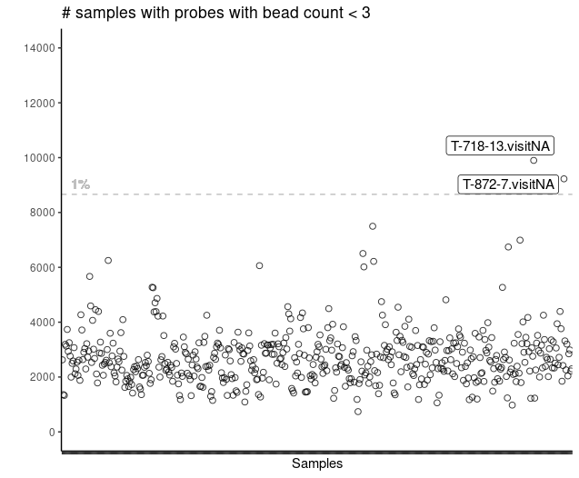

```r
# calculates the number of samples with bead count <3 for each probe in matrix of bead count values
bead <- beadcount(DIGPD_RG_Raw)
colnames(bead) <- gsub('X', '', gsub("\\.", "-", colnames(bead)))
colnames(bead) <- gsub("-visit", ".visit", colnames(bead))
all(colnames(bead)%in%digpd_meta$Sample_Name) #FALSE
colnames(bead)[-which(colnames(bead) %in% digpd_meta$Sample_Name)] #"01223D.visit1" "01223D.visit6"
colnames(bead)[colnames(bead)=="01223D.visit1"] <- "01223DX.visit1"
colnames(bead)[colnames(bead)=="01223D.visit6"] <- "01223DX.visit6"
all(colnames(bead)%in%digpd_meta$Sample_Name) #TRUE
bead <- bead[,match(digpd_meta$Sample_Name, colnames(bead))]
all(colnames(bead)==(digpd_meta$Sample_Name)) #TRUE

digpd_meta <- digpd_meta %>% mutate(beadcount = colSums(is.na(bead)))

#plot
digpd_meta %>%
  mutate(digpd_meta = factor(as.character(Sample_Name), levels = Sample_Name)) %>%
  ggplot(aes(x = Sample_Name, y = beadcount)) +
  geom_point(shape = 21, size = 2, alpha=0.8, col="black")+
  geom_hline(yintercept = 0.01*nrow(bead), linetype = 'dashed', color = 'gray') +
  geom_text(aes(x = 0, y = 0.01*nrow(bead)),
            label = '1%', vjust = -0.5, hjust = -0.5, color = 'gray')+
  labs(x = 'Samples', y = '', title = '# samples with probes with bead count < 3') +
  theme(axis.text.x = element_blank()) +
  scale_y_continuous(limits = c(0, 14000), breaks = seq(0,14000, 2000)) +
  theme_classic()+
  theme(axis.text.x = element_blank())+
  geom_label_repel(data = digpd_meta %>% filter(beadcount > (0.01*nrow(bead))),
aes(label = Sample_Name), size = 4, force = 15, nudge_x = 0.8, nudge_y = 0.5)

lowbead <- digpd_meta[digpd_meta$beadcount > (0.01*nrow(bead)),"Sample_Name"] #T-718-13.visitNA T-872-7.visitNA
```

Two samples flagged for low bead count.

## Average intensity

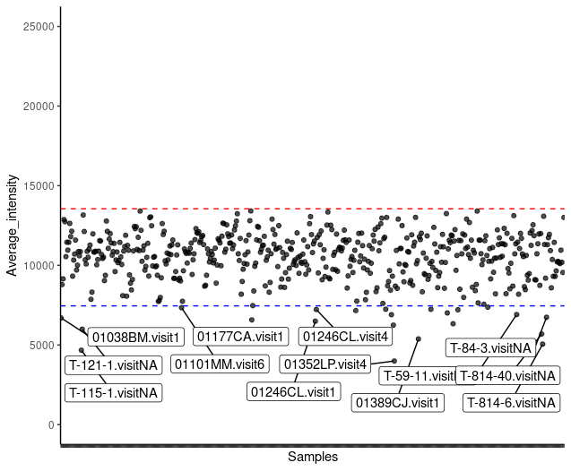

```r
green <- getGreen(DIGPD_RG_Raw)
red <- getRed(DIGPD_RG_Raw)
greenred <- green + red

# add to sampleInfo
digpd_meta <- digpd_meta %>% mutate(Average_intensity = colMeans(greenred))

digpd_meta %>%
  mutate(Sample_Name = factor(as.character(Sample_Name), levels = Sample_Name)) %>%
  ggplot(aes(x = Sample_Name, y = Average_intensity)) +
  geom_point(alpha = 0.7, color = 'black') + theme_classic() +
  theme(axis.text.x = element_blank()) +
  geom_hline(yintercept = mean(digpd_meta$Average_intensity) - 2*sd(digpd_meta$Average_intensity),
             linetype = 'dashed', col = 'blue')+
  geom_hline(yintercept = mean(digpd_meta$Average_intensity) + 2*sd(digpd_meta$Average_intensity),
             linetype = 'dashed', col = 'red') +
  geom_label_repel(data = digpd_meta %>%
                    filter(Average_intensity < mean(digpd_meta$Average_intensity) -
                             2*sd(digpd_meta$Average_intensity)),
                  aes(label = Sample_Name), force = 10, nudge_y = -2500, show.legend = F)+
  scale_y_continuous(limits = c(0, 25000)) +
  labs(x = 'Samples')

threshold <- mean(digpd_meta$Average_intensity) -2*sd(digpd_meta$Average_intensity)
length(lowintensity <- digpd_meta[digpd_meta$Average_intensity < threshold,"Sample_Name"]) #22
```

22 samples have average intensity below mean - 2 standard deviations.

## Outlier Detection - Lumi

This function is contained in the lumi package. The current outlier detection is based on the distance from the sample to the center (average of all samples). The assumption of the outlier detection is that there is only one single cluster and the distance from the sample to the center is Gaussian distributed.

The outlier is detected when its distance to the center is larger than a certain threshold. The threshold is calculated as Th * median distances to the center.

```r
betas_raw <- getBeta(DIGPD_RG_Raw)

Project_detout <- detectOutlier(betas_raw, Th = 1.5) # This calculates potential outliers
length(which(Project_detout)) #33
outlier_lumi <- names(which(Project_detout)) # This pulls the sample names of calculated outliers
outlier_lumi <- sort(outlier_lumi)
outlier_lumi
# [1] "01089GR.visit6"   "01187GZ.visit6"   "01288LC.visit4"   "T-13-2.visitNA"   "T-169-5.visitNA"
# [6] "T-17-14.visitNA"  "T-18-1.visitNA"   "T-2-23.visitNA"   "T-216-10.visitNA" "T-22-2.visitNA"
#[11] "T-224-10.visitNA" "T-24-1.visitNA"   "T-3-44.visitNA"   "T-30-2.visitNA"   "T-30-33.visitNA"
#[16] "T-325-15.visitNA" "T-35-1.visitNA"   "T-356-7.visitNA"  "T-360-19.visitNA" "T-4-9.visitNA"
#[21] "T-496-14.visitNA" "T-50-1.visitNA"   "T-50-2.visitNA"   "T-53-2.visitNA"   "T-550-3B.visitNA"
#[26] "T-599-13.visitNA" "T-599-18.visitNA" "T-7-7.visitNA"    "T-706-7.visitNA"  "T-711-8.visitNA"
#[31] "T-722-43.visitNA" "T-856-13.visitNA" "T-98-1.visitNA"
```

## Outlier Detection - wateRmelon

This is a wateRmelon package outlier detection method which uses the function pcout. Based on the robustly sphered data, semi-robust principal components are computed which are needed for determining distances for each observation. Separate weights for location and scatter outliers are computed based on these distances. The combined weights are used for outlier identification.

There are two criteria which have to pass a given threshold to be considered an outlier: iqr and mv. It is sometimes useful to take a look at samples which pass one but fail the second as well, perhaps these samples should still be removed?

```r
Project_pcout <- outlyx(getBeta(DIGPD_RG_Raw)) # This calculates potential outliers
#"pcout.png"

Project_pcout$Sample_ID <- rownames(Project_pcout)
out <- Project_pcout[which(Project_pcout$outliers == T),"Sample_ID"] # Pulling sample names deemed to be outliers
#These are the overlaps between iqr and mv methods
# [1] "T-13-2.visitNA"   "T-169-5.visitNA"  "T-17-14.visitNA"  "T-216-10.visitNA" "T-224-10.visitNA"
# [6] "T-24-1.visitNA"   "T-3-44.visitNA"   "T-30-2.visitNA"   "T-30-33.visitNA"  "T-35-1.visitNA"
#[11] "T-356-7.visitNA"  "T-360-19.visitNA" "T-496-14.visitNA" "T-50-1.visitNA"   "T-53-2.visitNA"
#[16] "T-550-3B.visitNA" "T-599-13.visitNA" "T-599-18.visitNA" "T-7-7.visitNA"    "T-722-43.visitNA"
#[21] "T-98-1.visitNA"

iqrout <- Project_pcout[which(Project_pcout$iqr == T),"Sample_ID"] # Pulling samples which failed the iqr threshold
# [1] "T-13-2.visitNA"   "T-169-5.visitNA"  "T-17-14.visitNA"  "T-18-1.visitNA"   "T-2-23.visitNA"
# [6] "T-216-10.visitNA" "T-22-2.visitNA"   "T-224-10.visitNA" "T-24-1.visitNA"   "T-3-44.visitNA"
#[11] "T-30-2.visitNA"   "T-30-33.visitNA"  "T-325-15.visitNA" "T-35-1.visitNA"   "T-356-7.visitNA"
#[16] "T-360-19.visitNA" "T-4-9.visitNA"    "T-496-14.visitNA" "T-50-1.visitNA"   "T-50-2.visitNA"
#[21] "T-53-2.visitNA"   "T-550-3B.visitNA" "T-599-13.visitNA" "T-599-18.visitNA" "T-7-7.visitNA"
#[26] "T-706-7.visitNA"  "T-711-8.visitNA"  "T-722-43.visitNA" "T-98-1.visitNA"

mvout <- Project_pcout[which(Project_pcout$mv == T),"Sample_ID"] # Pulling samples which failed the mv threshold
# [1] "01010GM.visit6"   "01062TM.visit6"   "01082PP.visit1"   "01086DP.visit4"   "01095PJ.visit1"
# [6] "01132DA.visit4"   "01167CC.visit1"   "01167CC.visit4"   "01168AF.visit1"   "01172BM.visit6"
#[11] "01181TR.visit1"   "01185HA.visit4"   "01189CY.visit6"   "01202MS.visit1"   "01202MS.visit6"
#[16] "01205DP.visit1"   "01205DP.visit4"   "01205DP.visit6"   "01220ME.visit4"   "01234LD.visit1"
#[21] "01234LD.visit2"   "01234LD.visit6"   "01263BG.visit1"   "01282BO.visit1"   "01282BO.visit4"
#[26] "01282BO.visit6"   "01286CT.visit1"   "01286CT.visit4"   "01298FJ.visit1"   "01298FJ.visit4"
#[31] "01311MC.visit4"   "01320LJ.visit1"   "01320LJ.visit4"   "01340GD.visit1"   "01340GD.visit4"
#[36] "01354GM.visit4"   "01367MA.visit1"   "01370JN.visit1"   "01370JN.visit4"   "01375SC.visit1"
#[41] "01375SC.visit4"   "T-13-2.visitNA"   "T-169-5.visitNA"  "T-17-14.visitNA"  "T-216-10.visitNA"
#[46] "T-224-10.visitNA" "T-24-1.visitNA"   "T-3-44.visitNA"   "T-30-2.visitNA"   "T-30-33.visitNA"
#[51] "T-35-1.visitNA"   "T-356-7.visitNA"  "T-360-19.visitNA" "T-49-7.visitNA"   "T-496-14.visitNA"
#[56] "T-50-1.visitNA"   "T-53-2.visitNA"   "T-550-3B.visitNA" "T-599-13.visitNA" "T-599-18.visitNA"
#[61] "T-7-7.visitNA"    "T-722-43.visitNA" "T-87-1.visitNA"   "T-98-1.visitNA"

#which are outliers in all 3?
outlier_melon <- out[out %in% iqrout & out %in% mvout]
outlier_melon
# [1] "T-13-2.visitNA"   "T-169-5.visitNA"  "T-17-14.visitNA"  "T-216-10.visitNA"
# [5] "T-224-10.visitNA" "T-24-1.visitNA"   "T-3-44.visitNA"   "T-30-2.visitNA"
# [9] "T-30-33.visitNA"  "T-35-1.visitNA"   "T-356-7.visitNA"  "T-360-19.visitNA"
#[13] "T-496-14.visitNA" "T-50-1.visitNA"   "T-53-2.visitNA"   "T-550-3B.visitNA"
#[17] "T-599-13.visitNA" "T-599-18.visitNA" "T-7-7.visitNA"    "T-722-43.visitNA"
#[21] "T-98-1.visitNA"
```

21 outliers were identified with wateRmelon, all of which were already identified with lumi.

## Inter-sample correlation

Intersample correlation analysis is performed to looked at pairwise corrlations between all the samples. Samples from the same tissues are expected to have high correlation (>90%). NOTE: Compare TERRE and DIG-PD in this plot. Expecting them to cluster similarly since they are both whole blood.

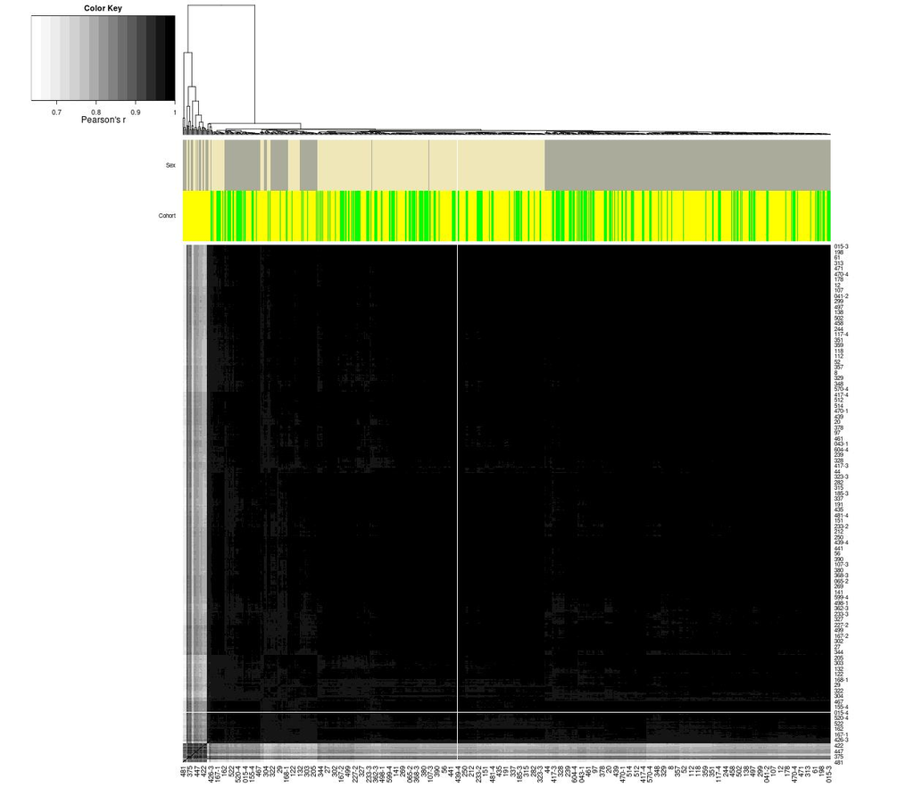

```r
#add TERRE samples
load("~/preprocessing/TERRE/TERRE_RG_Raw.RData")
terre_meta <- read.delim("~/preprocessing/TERRE/terre_meta_082022.txt")
terre_meta$Sample_Name <- terre_meta$patient
terre_meta <- terre_meta[,colnames(terre_meta) %in% colnames(digpd_meta)]
digpd_meta2 <- digpd_meta[,match(colnames(terre_meta),colnames(digpd_meta))]
all(colnames(digpd_meta2) == colnames(terre_meta)) #TRUE
terre_meta$Cohort <- "TERRE"
digpd_meta2$Cohort <- "DIGPD"
combined_meta <- rbind(digpd_meta2, terre_meta)

terre_betas_raw <- getBeta(PD_RG_Raw)
betas_raw2 <- betas_raw[match(rownames(terre_betas_raw),rownames(betas_raw)),]
combined_betas_raw <- cbind(betas_raw2, terre_betas_raw)
all(combined_meta$Sample_Name %in% colnames(combined_betas_raw))
combined_betas_raw <- combined_betas_raw[,colnames(combined_betas_raw) %in% combined_meta$Sample_Name]
combined_betas_raw <- combined_betas_raw[,match(combined_meta$Sample_Name, colnames(combined_betas_raw))]
all(colnames(combined_betas_raw)==combined_meta$Sample_Name) #TRUE
rm(PD_RG_Raw, terre_meta, terre_betas_raw, digpd_meta2, betas_raw2)

cor <-cor(combined_betas_raw,use="pairwise.complete.obs") #have saved this as it takes a while
save(cor, file="~/preprocessing/DIGPD/082022/DIGPD_TERRE_sample_cor.RData")

col.Sex <- gsub("M", "#AAAB9B", gsub("F", "#EFE7B8", combined_meta$reportedSex))
col.cohort <-gsub("DIGPD", "yellow", gsub("TERRE", "green", combined_meta$Cohort))

clab <- cbind(col.cohort,col.Sex)
colnames(clab) <- c("Cohort","Sex")

#Define custom dist and hclust functions for use with heatmaps
mydist=function(c) {dist(c,method="euclidian")}
myclust=function(c) {hclust(c,method="average")}

#par(mar=c(7,4,1,2)+0.1)
grey<-colorRampPalette(brewer.pal(n=9,"Greys"))

jpeg("~/preprocessing/DIGPD/082022/DIGPD_TERRE_intersamplecorrelation.jpeg", width = 1250, height = 1100)
intersamplecorrelation <- heatmap.3(cor,hclustfun=myclust, distfun=mydist,na.rm = TRUE, scale="none", dendrogram="col", margins=c(6,12), Rowv=TRUE, Colv=TRUE, symbreaks=FALSE, key=TRUE, symkey=FALSE, density.info="none", trace="none", ColSideColors=clab, labCol=rownames(combined_meta), labRow=rownames(combined_meta), cexRow=1, col=grey,ColSideColorsSize=5,KeyValueName="Pearson's r",keysize=1,cexCol=1.2)
print(intersamplecorrelation)
dev.off()

#getting per-sample summary
cor_summary <- colMeans(cor)
length(cor_summary[cor_summary<0.95]) #28 samples with poor correlation
samplecor <- names(cor_summary[cor_summary<0.95])
# [1] "T-13-2.visitNA"   "T-169-5.visitNA"  "T-17-14.visitNA"  "T-2-23.visitNA"   "T-216-10.visitNA"
# [6] "T-22-2.visitNA"   "T-224-10.visitNA" "T-24-1.visitNA"   "T-3-44.visitNA"   "T-30-2.visitNA"
#[11] "T-30-33.visitNA"  "T-325-15.visitNA" "T-35-1.visitNA"   "T-356-7.visitNA"  "T-360-19.visitNA"
#[16] "T-4-9.visitNA"    "T-496-14.visitNA" "T-50-1.visitNA"   "T-50-2.visitNA"   "T-53-2.visitNA"
#[21] "T-550-3B.visitNA" "T-599-13.visitNA" "T-599-18.visitNA" "T-7-7.visitNA"    "T-706-7.visitNA"
#[26] "T-711-8.visitNA"  "T-722-43.visitNA" "T-98-1.visitNA"

rm(combined_meta, combined_betas_raw)
```

A group of samples from DIGPD (yellow bar) do not correlate well with the rest of the samples. There is also one sample somewhere in the middle with very poor correlation.

## PCA

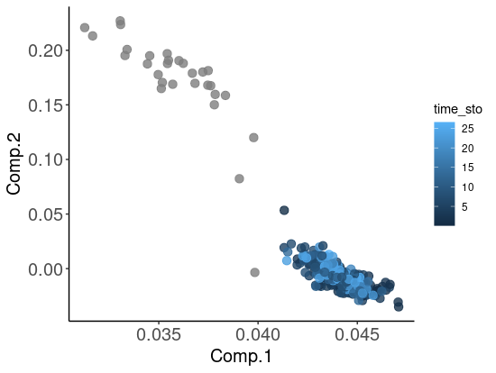

```r
PCA_full <-princomp(na.omit(betas_raw))
Loadings <-as.data.frame(unclass(PCA_full$loadings))
all(rownames(Loadings)==digpd_meta$Sample_Name) #FALSE
all(rownames(Loadings)%in%digpd_meta$Sample_Name) #TRUE
digpd_meta <- digpd_meta[match(rownames(Loadings),digpd_meta$Sample_Name),]
all(rownames(Loadings)==digpd_meta$Sample_Name) #TRUE
pca_meta <- cbind(digpd_meta, Loadings)
saveRDS(pca_meta,"~/preprocessing/DIGPD/082022/pca_meta.rds") #this has the PCA loadings

ggplot(pca_meta, aes(Comp.1, Comp.2, color=time_sto)) + geom_point(size = 3, alpha=0.8) +
theme_classic() + theme(axis.text = element_text(size =15),
axis.title = element_text(size =15))

#get outliers with PC1 loadings < 0.041 (this captures all NA values)
nrow(PCAout <- pca_meta[pca_meta$Comp.1<0.041,]) #29
summary(PCAout$time_sto) #all NA
```

29 outliers have no recorded time of sample storage. According to collaborators these samples were previously identified as outliers due to a long sample storage time.

## Epigenetic age prediction (Horvath)

If there are any large deviations from chronological age this could be a flag.

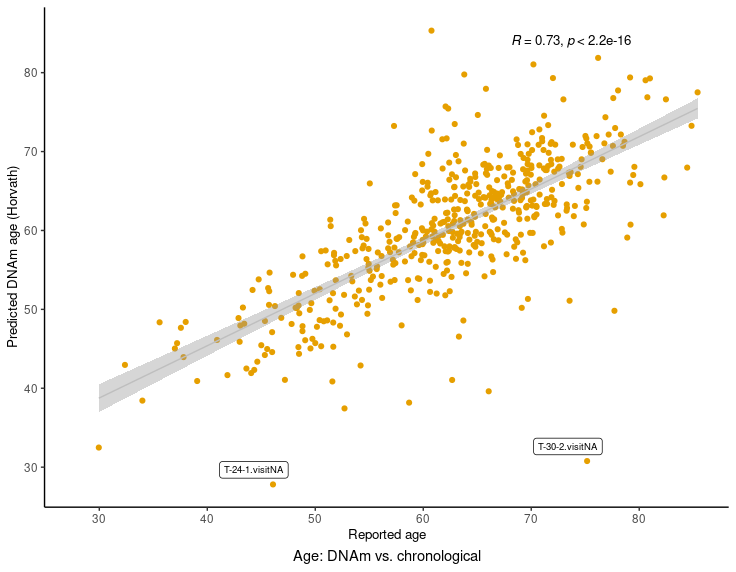

Horvath DNAm age

```r
epiage <- HorvathAge_NG(MSet, Tissue="WB")
#[1] "You have 335 out of 353 probes needed for the age clock. Missing 18 altogether."
#[1] "Resulting in 5 % missingness. Data will be imputed using training data."
epiage$SampleID <- gsub("X", "", gsub("\\.", "-", epiage$SampleID))
epiage$SampleID <- gsub("-visit", ".visit", epiage$SampleID)
write.table(epiage, file="~/preprocessing/DIGPD/082022/epiage_Horvath_raw.txt", sep="\t", row.names=F)
all(epiage$SampleID %in% digpd_meta$Sample_Name) #FALSE
epiage$SampleID[-which(epiage$SampleID %in% digpd_meta$Sample_Name)] #01223D.visit1 01223D.visit6
digpd_meta$Sample_Name[grep("01223D", digpd_meta$Sample_Name)] #01223DX.visit1 01223DX.visit6
epiage$SampleID[epiage$SampleID=="01223D.visit1"] <- "01223DX.visit1"
epiage$SampleID[epiage$SampleID=="01223D.visit6"] <- "01223DX.visit6"
all(epiage$SampleID %in% digpd_meta$Sample_Name) #TRUE

epiage <- epiage[match(digpd_meta$Sample_Name, epiage$SampleID),]
all.equal(epiage$SampleID, as.character(digpd_meta$Sample_Name)) #TRUE
digpd_meta$DNAmAge_Horvath <- epiage$DNAmAge

warnings <- epiage[grep("Warning",epiage$Comment),1:3]
#            SampleID  DNAmAge                             Comment
#102   01135HJ.visit1 56.14735  Warning: meanMethBySample is <0.25
#229   01263BG.visit1 66.37288  Warning: meanMethBySample is <0.25
#344  T-111-1.visitNA 55.10702  Warning: meanMethBySample is <0.25
#346  T-114-1.visitNA 61.93588  Warning: meanMethBySample is <0.25
#372   T-18-1.visitNA 70.88117  Warning: meanMethBySample is >0.35
#382 T-216-10.visitNA 49.81859  Warning: meanMethBySample is <0.25
#385   T-22-2.visitNA 52.21188  Warning: meanMethBySample is <0.25
#413  T-30-33.visitNA 59.09762  Warning: meanMethBySample is <0.25
#424  T-356-7.visitNA 71.55651  Warning: meanMethBySample is <0.25
#434 T-415-19.visitNA 65.71485  Warning: meanMethBySample is <0.25
#466 T-599-18.visitNA 79.76932  Warning: meanMethBySample is <0.25
#481  T-711-8.visitNA 40.85960  Warning: meanMethBySample is <0.25
#486 T-722-43.visitNA 56.98265  Warning: meanMethBySample is <0.25
#500  T-815-8.visitNA 45.71162  Warning: meanMethBySample is <0.25

min <- min(c(digpd_meta$Age, digpd_meta$DNAmAge_Horvath))
max <- max(c(digpd_meta$Age, digpd_meta$DNAmAge_Horvath))
digpd_meta$PD <- as.factor(digpd_meta$PD)

#with outlier samples labelled
ggplot(digpd_meta, aes(x = Age, y = DNAmAge_Horvath)) + geom_point(colour="#E69F00") + labs(x = "Reported age", y = "Predicted DNAm age (Horvath)", caption = "Age: DNAm vs. chronological") +  xlim(min,max) + ylim(min,max) +
  geom_smooth(method="lm", colour="grey", size=0.5) +
  stat_cor(method = "spearman", size = 3.5,label.x.npc = 0.7,label.y.npc = "top") +
  theme_bw() + theme(panel.border = element_blank(),
                     panel.grid.major = element_blank(),
                     panel.grid.minor = element_blank(),
                     axis.line = element_line(colour = "black"),
                     axis.text = element_text(),
                     axis.title = element_text(size = 10),
                     plot.caption = element_text(hjust = 0.5, size = rel(1)),
                     strip.background = element_blank(),
                     strip.text.x = element_blank())+
    geom_label_repel(data = digpd_meta %>% filter(DNAmAge_Horvath < 35 & Age > 40),
            aes(label = Sample_Name), size = 2.5, force = 10, nudge_x = -0.1, nudge_y = 0.1)

age_outliers <- c("T-24-1.visitNA","T-30-2.visitNA")

#split by sex and PD case/control status
ggplot(digpd_meta, aes(x = Age, y = DNAmAge_Horvath, group=PD, color=PD)) + geom_point() + scale_colour_manual(values=c("black","red")) + labs(x = "Reported age", y = "Predicted DNAm age (Horvath)", caption = "Age: DNAm vs. chronological") +  xlim(min,max) + ylim(min,max) +
  geom_smooth(method="lm", colour="grey", size=0.5) +
  stat_cor(method = "spearman", size = 3.5,label.x.npc = 0.7,label.y.npc = "bottom") +
  theme_classic() + facet_wrap(~reportedSex, nrow=2)
```

Most samples are well correlated between predicted and chronological age. There seem to be a couple outliers based on visual inspection.

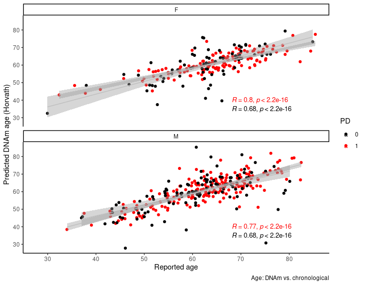

Horvath DNAm age by sex and PD status

PD patients have a slightly higher correlation between epigenetic age and chronological age than controls in either sex.

## Raw beta distibutions check

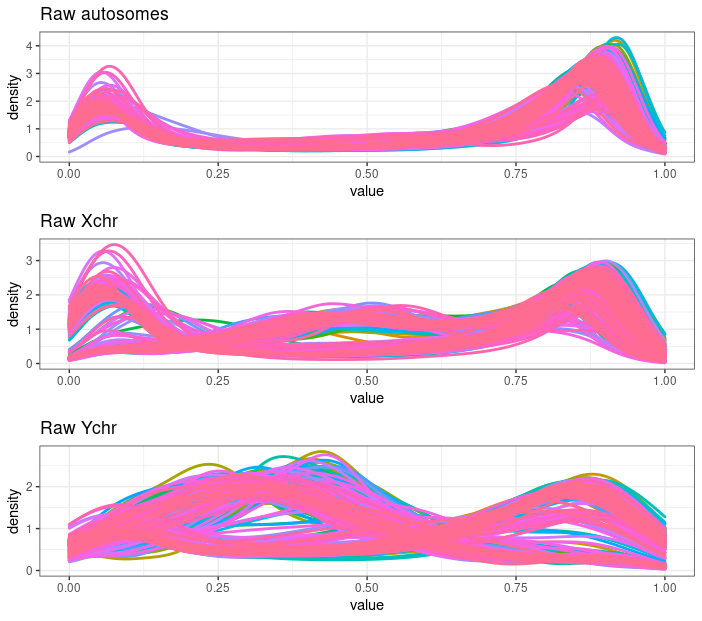

Raw data beta distributions

```r
#plotting beta distributions before
#split by sexchr/autosomes
KH_Anno <- read.csv("~/kobor_shared_coding_resource/EPIC_KH_Annotation.csv", row.names = 1)
length(Xprobes <- KH_Anno[KH_Anno$chr=="chrX","Name"]) #19,120
length(Yprobes <- KH_Anno[KH_Anno$chr=="chrY","Name"]) #561

## raw data
dim(MSet) #866238    523
digpd_meta <- digpd_meta[match(sampleNames(MSet), digpd_meta$Sample_Name),]
all.equal(sampleNames(MSet), as.character(digpd_meta$Sample_Name)) #TRUE
dim(MSet_raw_auto <- MSet[-which(rownames(MSet) %in% Xprobes|rownames(MSet) %in% Yprobes),]) #846604    523
dim(MSet_raw_X <- MSet[which(rownames(MSet) %in% Xprobes),]) #19097   523
dim(MSet_raw_Y <- MSet[which(rownames(MSet) %in% Yprobes),]) #537 523

### autosomes
Betas_raw_auto <-betas(MSet_raw_auto)
Beta_raw_auto_sample<-Betas_raw_auto[sample(1:nrow(Betas_raw_auto), 100000),]
Beta_raw_auto_sample_melted<- melt(Beta_raw_auto_sample)
Beta_raw_auto_Plot<-Beta_raw_auto_sample_melted[which(Beta_raw_auto_sample_melted$value >= 0),]
Beta_raw_auto_Plot<-merge(Beta_raw_auto_Plot,digpd_meta, by.x="Var2", by.y="Sample_Name")
raw_auto <- ggplot(Beta_raw_auto_Plot, aes(value, group=Var2, color=Var2))+
  geom_density(size=1)+theme_bw() + ggtitle("Raw autosomes") + theme(legend.position = "none")

### X
Betas_raw_X <-betas(MSet_raw_X)
Beta_raw_X_sample_melted<- melt(Betas_raw_X)
Beta_raw_X_Plot<-Beta_raw_X_sample_melted[which(Beta_raw_X_sample_melted$value >= 0),]
Beta_raw_X_Plot<-merge(Beta_raw_X_Plot,digpd_meta, by.x="Var2", by.y="Sample_Name")
raw_X <- ggplot(Beta_raw_X_Plot, aes(value, group=Var2, color=Var2))+
  geom_density(size=1)+theme_bw() + ggtitle("Raw Xchr") + theme(legend.position = "none")

### Y
Betas_raw_Y <-betas(MSet_raw_Y)
Beta_raw_Y_sample_melted<- melt(Betas_raw_Y)
Beta_raw_Y_Plot<-Beta_raw_Y_sample_melted[which(Beta_raw_Y_sample_melted$value >= 0),]
Beta_raw_Y_Plot<-merge(Beta_raw_Y_Plot,digpd_meta, by.x="Var2", by.y="Sample_Name")
raw_Y <- ggplot(Beta_raw_Y_Plot, aes(value, group=Var2, color=Var2))+
  geom_density(size=1)+theme_bw() + ggtitle("Raw Ychr") + theme(legend.position = "none")

#plot all
grid.arrange(raw_auto, raw_X, raw_Y, ncol=1, nrow=3)
```

Some samples have off distributions, particularly on the sex chromosomes. Will check these further.

### X and Y chr beta distributions check

Subsetting to samples flagged during earlier outlier/sex checks.

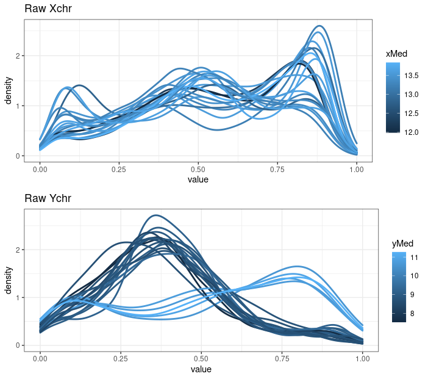

```r
#samples initially flagged for conumee sex confirmation
summary(as.factor(digpd_meta$conumeeSex))
#           F inconclusive            M         NA's
#          21            4           36          462

#flagged samples only, coloured by individual
X_raw <- ggplot(Beta_raw_X_Plot[complete.cases(Beta_raw_X_Plot$conumeeSex),], aes(value, group=Var2, color=Var2))+
  geom_density(size=1)+theme_bw() + ggtitle("Raw Xchr")
Y_raw <- ggplot(Beta_raw_Y_Plot[complete.cases(Beta_raw_Y_Plot$conumeeSex),], aes(value, group=Var2, color=Var2))+
  geom_density(size=1)+theme_bw() + ggtitle("Raw Ychr")
grid.arrange(X_raw, Y_raw, nrow=2, ncol=1)

#flagged samples only, coloured by sex
X_raw <- ggplot(Beta_raw_X_Plot[complete.cases(Beta_raw_X_Plot$conumeeSex),], aes(value, group=Var2, color=conumeeSex))+
  geom_density(size=1)+theme_bw() + ggtitle("Raw Xchr")
Y_raw <- ggplot(Beta_raw_Y_Plot[complete.cases(Beta_raw_Y_Plot$conumeeSex),], aes(value, group=Var2, color=conumeeSex))+
  geom_density(size=1)+theme_bw() + ggtitle("Raw Ychr")
grid.arrange(X_raw, Y_raw, nrow=2, ncol=1)

#flagged female samples only, coloured by xMed/yMed
X_raw <- ggplot(Beta_raw_X_Plot[complete.cases(Beta_raw_X_Plot$conumeeSex) & Beta_raw_X_Plot$conumeeSex=="F",], aes(value, group=Var2, color=xMed))+
  geom_density(size=1)+theme_bw() + ggtitle("Raw Xchr")
Y_raw <- ggplot(Beta_raw_Y_Plot[complete.cases(Beta_raw_Y_Plot$conumeeSex) & Beta_raw_Y_Plot$conumeeSex=="F",], aes(value, group=Var2, color=yMed))+
  geom_density(size=1)+theme_bw() + ggtitle("Raw Ychr")
grid.arrange(X_raw, Y_raw, nrow=2, ncol=1)
#female samples with high Ymed should be removed (accounts for odd Ychr distribution)

#flagged male samples only, coloured by xMed/yMed
X_raw <- ggplot(Beta_raw_X_Plot[complete.cases(Beta_raw_X_Plot$conumeeSex) & Beta_raw_X_Plot$conumeeSex=="M",], aes(value, group=Var2, color=xMed))+
  geom_density(size=1)+theme_bw() + ggtitle("Raw Xchr") #a few male samples with higher relative Xmed
Y_raw <- ggplot(Beta_raw_Y_Plot[complete.cases(Beta_raw_Y_Plot$conumeeSex) & Beta_raw_Y_Plot$conumeeSex=="M",], aes(value, group=Var2, color=yMed))+
  geom_density(size=1)+theme_bw() + ggtitle("Raw Ychr")
grid.arrange(X_raw, Y_raw, nrow=2, ncol=1)

#male samples coloured by flag
Beta_raw_X_Plot$flag <- as.character(Beta_raw_X_Plot$flag)
Beta_raw_X_Plot[Beta_raw_X_Plot$Var2 %in% Xchr_check,"flag"] <- "Xchr cluster"
Beta_raw_X_Plot[Beta_raw_X_Plot$Var2 %in% Ychr_check,"flag"] <- "Ychr missingness"
Beta_raw_X_Plot[Beta_raw_X_Plot$Var2 %in% M_Xchr_check,"flag"] <- "M Xchr check"
Beta_raw_X_Plot[Beta_raw_X_Plot$Var2 %in% MF_Xchr_check,"flag"] <- "MF Xchr check"

X_raw <- ggplot(Beta_raw_X_Plot[complete.cases(Beta_raw_X_Plot$conumeeSex) & Beta_raw_X_Plot$conumeeSex=="M",], aes(value, group=Var2, color=flag))+
  geom_density(size=1)+theme_bw() + ggtitle("Raw Xchr")

Beta_raw_Y_Plot$flag <- as.character(Beta_raw_Y_Plot$flag)
Beta_raw_Y_Plot[Beta_raw_Y_Plot$Var2 %in% Xchr_check,"flag"] <- "Xchr cluster"
Beta_raw_Y_Plot[Beta_raw_Y_Plot$Var2 %in% Ychr_check,"flag"] <- "Ychr missingness"
Beta_raw_Y_Plot[Beta_raw_Y_Plot$Var2 %in% M_Xchr_check,"flag"] <- "M Xchr check"
Beta_raw_Y_Plot[Beta_raw_Y_Plot$Var2 %in% MF_Xchr_check,"flag"] <- "MF Xchr check"

Y_raw <- ggplot(Beta_raw_Y_Plot[complete.cases(Beta_raw_Y_Plot$conumeeSex) & Beta_raw_Y_Plot$conumeeSex=="M",], aes(value, group=Var2, color=flag))+
  geom_density(size=1)+theme_bw() + ggtitle("Raw Ychr")

grid.arrange(X_raw, Y_raw, nrow=2, ncol=1)

#females coloured by flag
Beta_raw_X_Plot[Beta_raw_X_Plot$Var2 %in% F_Xchr_check,"flag"] <- "F Xchr check"
X_raw <- ggplot(Beta_raw_X_Plot[complete.cases(Beta_raw_X_Plot$conumeeSex) & Beta_raw_X_Plot$conumeeSex=="F",], aes(value, group=Var2, color=flag))+
  geom_density(size=1)+theme_bw() + ggtitle("Raw Xchr")

Beta_raw_Y_Plot[Beta_raw_Y_Plot$Var2 %in% F_Xchr_check,"flag"] <- "F Xchr check"
Y_raw <- ggplot(Beta_raw_Y_Plot[complete.cases(Beta_raw_Y_Plot$conumeeSex) & Beta_raw_Y_Plot$conumeeSex=="F",], aes(value, group=Var2, color=flag))+
  geom_density(size=1)+theme_bw() + ggtitle("Raw Ychr")

grid.arrange(X_raw, Y_raw, nrow=2, ncol=1)

#collecting list of samples flagged by conumee and beta distribution
length(betadist_yMed <- digpd_meta[complete.cases(digpd_meta$conumeeSex) & digpd_meta$conumeeSex=="F" & digpd_meta$yMed>10,"Sample_Name"]) #5
betadist_yMed
#01066SF.visit4  01210OF.visit4  T-169-5.visitNA T-23-7.visitNA  T-98-1.visitNA

length(betadist <- unique(c(as.character(betadist_F), as.character(MF_Xchr_check)))) #13 total samples
```

Samples with high yMed should be excluded.

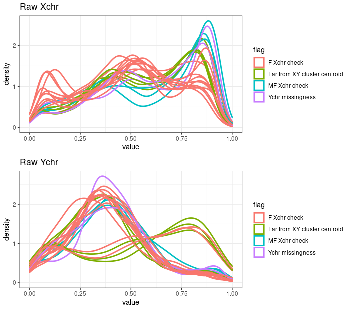

X and Y chr beta distributions for female samples intially flagged in sex check: by flag

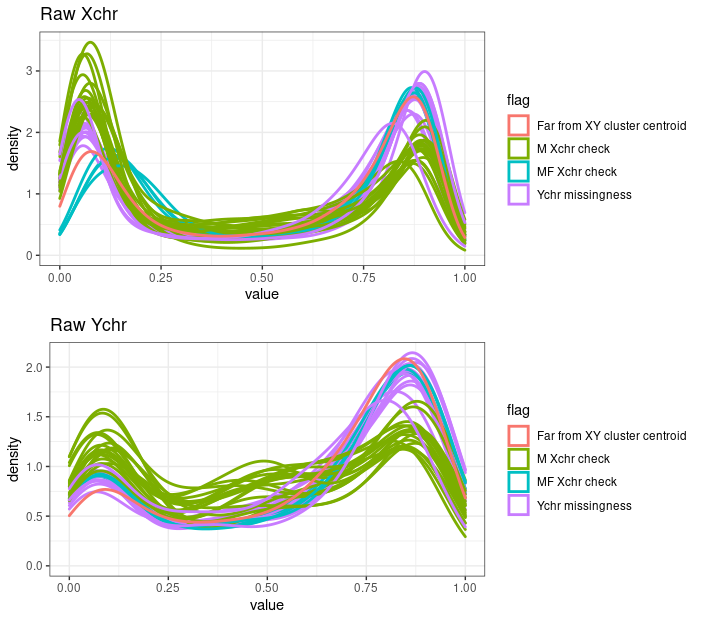

X and Y chr beta distributions for male samples intially flagged in sex check: by flag

Samples with flag “MF Xchr check” should be excluded. These loaded away from clusters on Xchr PC2, and also have odd beta distributions in both sexes on the X chromosome.

## Summary of flagged samples

For each metric here I’ll only list additional samples not identified by the metrics above it.

ewastools control metrics: 19

minfi M/U intensity: 0

sex mismatches: 6

SNP control probes clustering: 0

SNP outliers: 13

detection p-value: 1

bead count: 2

average intensity: 22

lumi outlier detection: 30

wateRmelon outlier detection: 0

inter-sample correlation: 0

PCA clustering: 0

epigenetic age: 0

In total there are **98** samples flagged for removal.

## Samples to remove

```r
to_remove <- unique(c(as.character(bisulfite_fail), as.character(sex_mismatch$Sample_Name), as.character(SNPoutliers), badSamps, as.character(lowbead), as.character(lowintensity), outlier_lumi, samplecor, as.character(PCAout$Sample_Name), age_outliers, betadist))
to_remove #98 in total
length(to_remove[grep("visit1", to_remove)]) + length(to_remove[grep("visitNA", to_remove)]) #64 from first time point

#comparing with previous round of preprocessing
prev_outliers <- c("01089GR.visit6",   "01187GZ.visit6",   "01288LC.visit4",   "T-13-2.visitNA",   "T-169-5.visitNA",
"T-17-14.visitNA",  "T-18-1.visitNA",   "T-2-23.visitNA",   "T-216-10.visitNA", "T-22-2.visitNA",
"T-224-10.visitNA", "T-24-1.visitNA",   "T-3-44.visitNA",   "T-30-2.visitNA",   "T-30-33.visitNA",
"T-325-15.visitNA", "T-35-1.visitNA",   "T-356-7.visitNA",  "T-360-19.visitNA", "T-4-9.visitNA",
"T-496-14.visitNA", "T-50-1.visitNA",   "T-50-2.visitNA",   "T-53-2.visitNA",   "T-550-3B.visitNA",
"T-599-13.visitNA", "T-599-18.visitNA", "T-7-7.visitNA",    "T-706-7.visitNA",  "T-711-8.visitNA",
"T-722-43.visitNA", "T-856-13.visitNA", "T-98-1.visitNA",   "01265CD.visit1",   "01158LS.visit6",
"01334CJ.visit4",   "T-415-19.visitNA", "T-819-4.visitNA",  "01264GC.visit1" )
length(prev_outliers[prev_outliers %in% to_remove]) #34 of 39 flagged here

#remove and save object
dim(DIGPD_RG_Raw) # 1051943     523
dim(DIGPD_RG_Raw_noout <- DIGPD_RG_Raw[,-which(sampleNames(DIGPD_RG_Raw) %in% to_remove)]) #1051943     425
save(DIGPD_RG_Raw_noout, file="~/preprocessing/DIGPD/082022/DIGPD_RG_Raw_noout.RData")
```

# Normalization

Since analysis will be sex stratified, sex chromosomes can be retained; however, special considerations should be taken into account for normalization due to differing DNAm distirbutions of sex chromosomes and autosomes (e.g. from X inactivation).

I will use the “adjustedFunnorm” function from the wateRmelon package (Wang et al., Bioinformatics 2022). This approach first normalizes autosomes, then uses the methylation values from the autosomes to “correct” methylation measurements on the sex chromosomes. Adjusted Funnorm may reduce artificial bias between sexes as compared to traditional Funnorm.

The adjustedFunnorm function includes noob background and dye bias correction by default.

## adjustedFunnorm

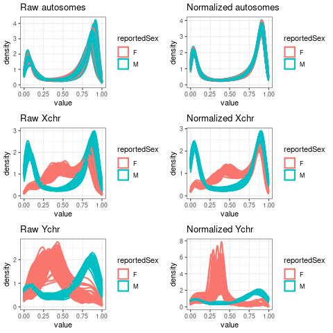

Beta distributions before and after normalization

```r
write.csv(digpd_meta, file="~/preprocessing/DIGPD/082022/digpd_meta_08302022.csv")
DIGPD_RG_norm <- adjustedFunnorm(DIGPD_RG_Raw_noout)
save(DIGPD_RG_norm, file="~/preprocessing/DIGPD/082022/DIGPD_RG_norm.RData")
nrow(digpd_meta_sub <- digpd_meta[digpd_meta$Sample_Name %in% sampleNames(DIGPD_RG_norm),]) #425

#plotting beta distributions before/after normalization
#split by sexchr/autosomes
KH_Anno <- read.csv("~/kobor_shared_coding_resource/EPIC_KH_Annotation.csv", row.names = 1)
length(Xprobes <- KH_Anno[KH_Anno$chr=="chrX","Name"]) #19,120
length(Yprobes <- KH_Anno[KH_Anno$chr=="chrY","Name"]) #561

## raw data
MSet_raw <- preprocessRaw(DIGPD_RG_Raw_noout)
dim(MSet_raw) #866238    425
all(sampleNames(MSet_raw) %in% as.character(digpd_meta_sub$Sample_Name)) #TRUE
digpd_meta_sub <- digpd_meta_sub[match(sampleNames(MSet_raw), digpd_meta_sub$Sample_Name),]
all(sampleNames(MSet_raw) == as.character(digpd_meta_sub$Sample_Name)) #TRUE
dim(MSet_raw_auto <- MSet_raw[-which(rownames(MSet_raw) %in% Xprobes|rownames(MSet_raw) %in% Yprobes),]) #846604    425
dim(MSet_raw_X <- MSet_raw[which(rownames(MSet_raw) %in% Xprobes),]) #19097   425
dim(MSet_raw_Y <- MSet_raw[which(rownames(MSet_raw) %in% Yprobes),]) #537 425

### autosomes
Betas_raw_auto <-betas(MSet_raw_auto)
Beta_raw_auto_sample<-Betas_raw_auto[sample(1:nrow(Betas_raw_auto), 100000),]
Beta_raw_auto_sample_melted<- melt(Beta_raw_auto_sample)
Beta_raw_auto_Plot<-Beta_raw_auto_sample_melted[which(Beta_raw_auto_sample_melted$value >= 0),]
Beta_raw_auto_Plot<-merge(Beta_raw_auto_Plot,digpd_meta_sub, by.x="Var2", by.y="Sample_Name")
raw_auto <- ggplot(Beta_raw_auto_Plot, aes(value, group=Var2, color=reportedSex))+
  geom_density(size=1)+theme_bw() + ggtitle("Raw autosomes")

### X
Betas_raw_X <-betas(MSet_raw_X)
Beta_raw_X_sample_melted<- melt(Betas_raw_X)
Beta_raw_X_Plot<-Beta_raw_X_sample_melted[which(Beta_raw_X_sample_melted$value >= 0),]
Beta_raw_X_Plot<-merge(Beta_raw_X_Plot,digpd_meta_sub, by.x="Var2", by.y="Sample_Name")
raw_X <- ggplot(Beta_raw_X_Plot, aes(value, group=Var2, color=reportedSex))+
  geom_density(size=1)+theme_bw() + ggtitle("Raw Xchr")

### Y
Betas_raw_Y <-betas(MSet_raw_Y)
Beta_raw_Y_sample_melted<- melt(Betas_raw_Y)
Beta_raw_Y_Plot<-Beta_raw_Y_sample_melted[which(Beta_raw_Y_sample_melted$value >= 0),]
Beta_raw_Y_Plot<-merge(Beta_raw_Y_Plot,digpd_meta_sub, by.x="Var2", by.y="Sample_Name")
raw_Y <- ggplot(Beta_raw_Y_Plot, aes(value, group=Var2, color=reportedSex))+
  geom_density(size=1)+theme_bw() + ggtitle("Raw Ychr")

## normalized data
dim(DIGPD_RG_norm) #865859    425
dim(GSet_norm_auto <- DIGPD_RG_norm[-which(rownames(DIGPD_RG_norm) %in% Xprobes|rownames(DIGPD_RG_norm) %in% Yprobes),]) # 846232    425
dim(GSet_norm_X <- DIGPD_RG_norm[which(rownames(DIGPD_RG_norm) %in% Xprobes),]) #19090   425
dim(GSet_norm_Y <- DIGPD_RG_norm[which(rownames(DIGPD_RG_norm) %in% Yprobes),]) #537 425

### autosomes
Betas_norm_auto <-getBeta(GSet_norm_auto)
Beta_norm_auto_sample<-Betas_norm_auto[sample(1:nrow(Betas_norm_auto), 100000),]
Beta_norm_auto_sample_melted<- melt(Beta_norm_auto_sample)
Beta_norm_auto_Plot<-Beta_norm_auto_sample_melted[which(Beta_norm_auto_sample_melted$value >= 0),]
Beta_norm_auto_Plot<-merge(Beta_norm_auto_Plot,digpd_meta_sub, by.x="Var2", by.y="Sample_Name")
norm_auto <- ggplot(Beta_norm_auto_Plot, aes(value, group=Var2, color=reportedSex))+
  geom_density(size=1)+theme_bw() + ggtitle("Normalized autosomes")

### X
Betas_norm_X <-getBeta(GSet_norm_X)
Beta_norm_X_sample_melted<- melt(Betas_norm_X)
Beta_norm_X_Plot<-Beta_norm_X_sample_melted[which(Beta_norm_X_sample_melted$value >= 0),]
Beta_norm_X_Plot<-merge(Beta_norm_X_Plot,digpd_meta_sub, by.x="Var2", by.y="Sample_Name")
norm_X <- ggplot(Beta_norm_X_Plot, aes(value, group=Var2, color=reportedSex))+
  geom_density(size=1)+theme_bw() + ggtitle("Normalized Xchr")

### Y
Betas_norm_Y <-getBeta(GSet_norm_Y)
Beta_norm_Y_sample_melted<- melt(Betas_norm_Y)
Beta_norm_Y_Plot<-Beta_norm_Y_sample_melted[which(Beta_norm_Y_sample_melted$value >= 0),]
Beta_norm_Y_Plot<-merge(Beta_norm_Y_Plot,digpd_meta_sub, by.x="Var2", by.y="Sample_Name")
norm_Y <- ggplot(Beta_norm_Y_Plot, aes(value, group=Var2, color=reportedSex))+
  geom_density(size=1)+theme_bw() + ggtitle("Normalized Ychr")

#plot all
png("~/preprocessing/DIGPD/082022/beta_distr_norm_425n.png")
grid.arrange(raw_auto, norm_auto, raw_X, norm_X, raw_Y, norm_Y, ncol=2, nrow=3)
dev.off()

# checking sexchrs by flag
Beta_norm_X_Plot$flag <- as.character(Beta_norm_X_Plot$flag)
Beta_norm_X_Plot[Beta_norm_X_Plot$Var2 %in% F_Xchr_check,"flag"] <- "F Xchr check"
#Beta_norm_X_Plot[Beta_norm_X_Plot$Var2 %in% Ychr_check,"flag"] <- "Ychr missingness"
Beta_norm_X_Plot[Beta_norm_X_Plot$Var2 %in% M_Xchr_check,"flag"] <- "M Xchr check"
Beta_norm_X_Plot[Beta_norm_X_Plot$Var2 %in% MF_Xchr_check,"flag"] <- "MF Xchr check"
X_norm <- ggplot(Beta_norm_X_Plot[complete.cases(Beta_norm_X_Plot$conumeeSex) & Beta_norm_X_Plot$conumeeSex=="F",], aes(value, group=Var2, color=flag))+
geom_density(size=1)+theme_bw() + ggtitle("Normalized Xchr")

Beta_norm_Y_Plot$flag <- as.character(Beta_norm_Y_Plot$flag)
Beta_norm_Y_Plot[Beta_norm_Y_Plot$Var2 %in% Xchr_check,"flag"] <- "Xchr cluster"
Beta_norm_Y_Plot[Beta_norm_Y_Plot$Var2 %in% Ychr_check,"flag"] <- "Ychr missingness"
Beta_norm_Y_Plot[Beta_norm_Y_Plot$Var2 %in% M_Xchr_check,"flag"] <- "M Xchr check"
Beta_norm_Y_Plot[Beta_norm_Y_Plot$Var2 %in% MF_Xchr_check,"flag"] <- "MF Xchr check"
Y_norm <- ggplot(Beta_norm_Y_Plot[complete.cases(Beta_norm_Y_Plot$conumeeSex) & Beta_norm_Y_Plot$conumeeSex=="M",], aes(value, group=Var2, color=flag))+
geom_density(size=1)+theme_bw() + ggtitle("Normalized Ychr")

grid.arrange(X_norm, Y_norm, nrow=2, ncol=1)
```

After outlier removal and normalization, beta distributions for autosomes and sex chromosomes look as expected.

# List of probes to filter

I will first calculate the QC metrics/list of probes to remove using the raw object (BEFORE normalization). This is because funnorm imputes missing values, which might make probes that failed technical checks appear to be usable after normalization. Then I’ll remove those probes from the normalized object.

Probes to filter out:

1. Those with low bead count/too many NA’s (excluding female Ychr background signal)
2. Cross-hybridizing probes
3. Polymorphic probes

## Poor performing probes

Detection p values indicate whether a particular methylation intensity is statistically different from the average intensity over the negative control probes/background. P values which are greater than 0.01 are considered poor quality measurements.

```r
#getting detection p-values and bead count again (not saved)
detP <- minfi::detectionP(DIGPD_RG_Raw_noout)

#replacing female Ychr values with NA so they don't count toward total
detP_noY <- detP
detP_noY[rownames(detP_noY) %in% Yprobes,colnames(detP_noY) %in% digpd_meta_sub[digpd_meta_sub$reportedSex=="F","Sample_Name"]] <- NA
detP <- detP[,match(digpd_meta_sub$Sample_Name, colnames(detP))]
detP_noY <- detP_noY[,match(digpd_meta_sub$Sample_Name, colnames(detP_noY))]
all(colnames(detP)==(as.character(digpd_meta_sub$Sample_Name))) #TRUE
all(colnames(detP_noY)==(as.character(digpd_meta_sub$Sample_Name))) #TRUE

bead <- beadcount(DIGPD_RG_Raw_noout)
colnames(bead) <- gsub('X', '', gsub("\\.", "-", colnames(bead)))
colnames(bead) <- gsub("-visit", ".visit", colnames(bead))
all(colnames(bead)%in%digpd_meta_sub$Sample_Name) #FALSE
colnames(bead)[-which(colnames(bead) %in% digpd_meta_sub$Sample_Name)] #"01223D.visit1" "01223D.visit6"
colnames(bead)[colnames(bead)=="01223D.visit1"] <- "01223DX.visit1"
colnames(bead)[colnames(bead)=="01223D.visit6"] <- "01223DX.visit6"
all(colnames(bead)%in%digpd_meta_sub$Sample_Name) #TRUE
bead <- bead[,match(digpd_meta_sub$Sample_Name, colnames(bead))]
all(colnames(bead)==(as.character(digpd_meta_sub$Sample_Name))) #TRUE

# create a dummy matrix
bad_probes <- matrix(data = F, nrow = nrow(detP), ncol = ncol(detP),
                        dimnames = list(rownames(detP), colnames(detP))) %>% as.data.frame

# now let us put 'TRUE' where detp > 0.01, or beadcount is < 3
bad_probes[is.na(bead)] <- T
bad_probes[detP_noY > 0.01] <- T #excluding female Y probes

#Number of probes that had a significant amount of bad performing probes:
n <- ncol(DIGPD_RG_Raw_noout)
bad_probes_count <- rowSums(bad_probes)
sum(bad_probes_count > 0.010*n) #62651
sum(bad_probes_count > 0.025*n) #28289
sum(bad_probes_count > 0.05*n) #9622

# bad probes, remove if > 5% missing
probe_anno <- tibble(probe_ID = rownames(detP)) %>%
  mutate(number_bad_probes = bad_probes_count)
probe_bad <- probe_anno %>% filter(number_bad_probes > 0.05*n)  %>% pull(probe_ID)  %>%  as.data.frame()
#9,622 bad probes

length(probe_bad$.[probe_bad$. %in% featureNames(DIGPD_RG_norm)])
#[1] 9615
```

## Cross-hybrizing probes

Probes which are predicted to unintentionally bind to other regions throughout the genome other than their target region should be removed (cross hybridizing probes). Pidsley et. al (2016) did analysis to measure EPIC cross reactive probes. I will remove any probes which have been predicted to cross hybridize on the EPIC array.

```r
# from Pidsley (includes Price probes)
EPIC_Cross_Hybrid <- read.csv("~/kobor_shared_coding_resource/EPIC_Cross_reactive_probes.csv" , row.names = 1)
length(EPIC_CH_Probes <- rownames(EPIC_Cross_Hybrid)) # 43254 cross hybridizing probes
length(EPIC_CH_Probes_additional <- EPIC_CH_Probes[EPIC_CH_Probes %in% featureNames(DIGPD_RG_norm)]) #43177
length(EPIC_CH_Probes_additional <- EPIC_CH_Probes_additional[-which(EPIC_CH_Probes_additional %in% probe_bad$.)]) #42749
```

## Polymorphic probes

We remove probes which either measure a CpG which is also a SNP (polymorphic CpG) or contain a SNP within the probe. Only SNPs present in >5% of the population were removed. The additional SNP annotation was produced by Dr. Kasper Hansen. This includes SNPs located at the CpG site measured, some additional sites located within the probes and SNPs located at the single base pair extension location.

```r
# Subsetting fdata for probes with CpG_maf values less than 0.05 or NA
CpG <- rownames(KH_Anno)[(KH_Anno$CpG_maf < 0.05) | is.na(KH_Anno$CpG_maf)]

# Subsetting KH_Annoa for probes with SBE_maf values less than 0.05 or NA
SBE <- rownames(KH_Anno)[(KH_Anno$SBE_maf < 0.05) | is.na(KH_Anno$SBE_maf)]

# Finding the overlapping row names
No_SNP_Conf <- intersect(CpG, SBE) #these are the probes to KEEP
length(Conf_Probes <- rownames(KH_Anno)[-which(rownames(KH_Anno) %in% No_SNP_Conf)]) #11,726 probes to remove
length(Conf_Probes_additional <- Conf_Probes[Conf_Probes %in% featureNames(DIGPD_RG_norm)]) #11,681
length(Conf_Probes_additional <- Conf_Probes_additional[-which(Conf_Probes_additional %in% probe_bad$.|Conf_Probes_additional %in% EPIC_CH_Probes)]) #9,761
```

# Probe filtering

```r
length(probes_to_filter <- unique(c(as.character(probe_bad$.), EPIC_CH_Probes, Conf_Probes))) #62,244
length(probes_to_filter[probes_to_filter %in% featureNames(DIGPD_RG_norm)]) #62,125
dim(DIGPD_RG_Raw_noout) #1051943     425
dim(DIGPD_RG_norm) #865859    425 (control probes removed after normalization)
dim(DIGPD_RG_filtered <- DIGPD_RG_norm[-which(featureNames(DIGPD_RG_norm) %in% probes_to_filter),]) #803734    425
save(DIGPD_RG_filtered, file="~/preprocessing/DIGPD/082022/DIGPD_RG_filtered.RData")

rm(DIGPD_RG_norm, detP, detP_noY, bad_probes, bead)
write.csv(digpd_meta_sub, file="~/preprocessing/DIGPD/082022/digpd_meta_prbfilter.csv", row.names=F)
```

# Predicting cell type proportions

I will predict cell type using the Houseman algorithm and IDOL-picked reference probes on RAW data. Note ECC11 in-house function produced odd estimates, so I am using the estimateCellCounts2 function.

### IDOL reference (estimateCellCounts2)

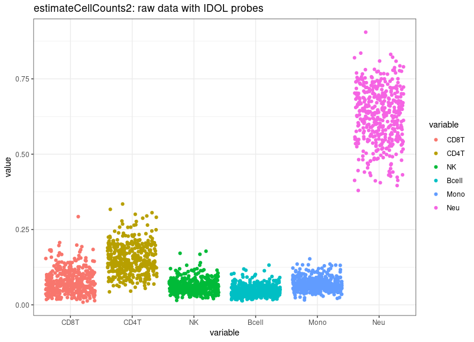

ECC2 predicted cell type proportions with IDOL reference

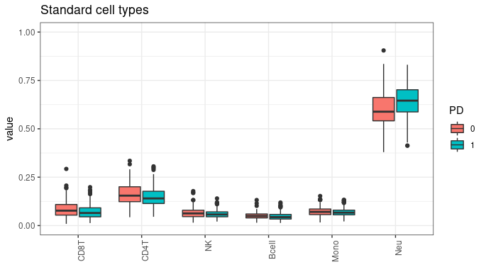

Predicted cell type proportions split by PD status, with sexes combined

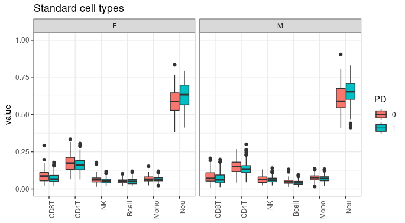

Predicted cell type proportions split by PD status, with sex stratification

```r
source('~/kobor_shared_coding_resource/ECC2_SS.R') #manually calls experimenthub object created 9/2/22
data("IDOLOptimizedCpGs")
cellprop_ecc2_idol <- ECC2_SS(DIGPD_RG_Raw_noout, compositeCellType = "Blood", probeSelect="IDOL", IDOLOptimizedCpGs = IDOLOptimizedCpGs, referencePlatform = "IlluminaHumanMethylationEPIC")

#estimation with extended cell type reference
#library(ExperimentHub)
#hub <- ExperimentHub()
#query(hub, "FlowSorted.BloodExtended.EPIC")
#FlowSorted.BloodExtended.EPIC <- hub[["EH5425"]]
#load("~/kobor_shared_coding_resource/FlowSorted.BloodExtended.EPIC.RData")
#library("FlowSorted.Blood.EPIC")

#cellprop_ecc2_idol_ext <- estimateCellCounts2(DIGPD_RG_Raw_noout, compositeCellType = "Blood", probeSelect="IDOL", IDOLOptimizedCpGs = IDOLOptimizedCpGsBloodExtended, referencePlatform = "IlluminaHumanMethylationEPIC", cellTypes=c("Neu","Eos","Bas","Mono","Bnv","Bmem","CD4nv","CD4mem","Treg","CD8nv","CD8mem","NK"), referenceset="FlowSorted.BloodExtended.EPIC")

counts <- cellprop_ecc2_idol$counts
counts <- counts[match(digpd_meta$Sample_Name, rownames(counts)),]
all.equal(rownames(counts), as.character(digpd_meta$Sample_Name)) #TRUE
digpd_meta <- cbind(digpd_meta, counts)
write.csv(digpd_meta[,2:ncol(digpd_meta)], file="~/preprocessing/DIGPD/082022/digpd_meta_cellprop.csv", row.names=F)

cellprop_melt <- melt(digpd_meta[,37:42])
ggplot(cellprop_melt, aes(x=variable, y=value, col=variable)) + geom_jitter() + theme_bw() + ggtitle("estimateCellCounts2: raw data with IDOL probes")

#plot by PD
cellprop_melt <- melt(digpd_meta[,c(3,4,36:41)], id.vars=c("reportedSex","PD"))
cellprop_melt$PD <- as.factor(cellprop_melt$PD)
ggplot(cellprop_melt, aes(x=variable, y=value, fill=PD)) + geom_boxplot() + theme_bw() + ggtitle("Standard cell types") + theme(axis.text.x=element_text(angle=90, hjust=1), axis.title.x=element_blank()) + ylim(c(0,1))

#plot by sex and PD
ggplot(cellprop_melt, aes(x=variable, y=value, fill=PD)) + geom_boxplot() + theme_bw() + ggtitle("Standard cell types") + theme(axis.text.x=element_text(angle=90, hjust=1), axis.title.x=element_blank()) + ylim(c(0,1)) + facet_wrap(~reportedSex)

### visit 1 only
digpd_meta_sub <- digpd_meta[-which(digpd_meta$visite>1),]

#plot by PD
cellprop_melt <- melt(digpd_meta_sub[,c(3,4,36:41)], id.vars=c("reportedSex","PD"))
cellprop_melt$PD <- as.factor(cellprop_melt$PD)
ggplot(cellprop_melt, aes(x=variable, y=value, fill=PD)) + geom_boxplot() + theme_bw() + ggtitle("Standard cell types") + theme(axis.text.x=element_text(angle=90, hjust=1), axis.title.x=element_blank()) + ylim(c(0,1))

#plot by sex and PD
ggplot(cellprop_melt, aes(x=variable, y=value, fill=PD)) + geom_boxplot() + theme_bw() + ggtitle("Standard cell types") + theme(axis.text.x=element_text(angle=90, hjust=1), axis.title.x=element_blank()) + ylim(c(0,1)) + facet_wrap(~reportedSex)

########## standard cell types significance test: all time points
#testing significance: standard cell types, sexes combined
pvals_std <- c("CD8T"=t.test(digpd_meta[digpd_meta$PD==0,"CD8T"],digpd_meta[digpd_meta$PD==1,"CD8T"])$p.value,
               "CD4T"=t.test(digpd_meta[digpd_meta$PD==0,"CD4T"],digpd_meta[digpd_meta$PD==1,"CD4T"])$p.value,
               "NK"=t.test(digpd_meta[digpd_meta$PD==0,"NK"],digpd_meta[digpd_meta$PD==1,"NK"])$p.value,
               "Bcell"=t.test(digpd_meta[digpd_meta$PD==0,"Bcell"],digpd_meta[digpd_meta$PD==1,"Bcell"])$p.value,
               "Mono"=t.test(digpd_meta[digpd_meta$PD==0,"Mono"],digpd_meta[digpd_meta$PD==1,"Mono"])$p.value,
               "Neu"=t.test(digpd_meta[digpd_meta$PD==0,"Neu"],digpd_meta[digpd_meta$PD==1,"Neu"])$p.value)
sort(pvals_std)
#         Neu         CD8T         CD4T           NK        Bcell         Mono
#5.510459e-06 6.655971e-04 4.481646e-03 1.708378e-02 1.902877e-02 9.101616e-02

sort(p.adjust(pvals_std))
#         Neu         CD8T         CD4T           NK        Bcell         Mono
#3.306276e-05 3.327986e-03 1.792658e-02 5.125135e-02 5.125135e-02 9.101616e-02

#testing significance: standard cell types, females
pvals_std_F <- c("CD8T"=t.test(digpd_meta[digpd_meta$PD==0&digpd_meta$reportedSex=="F","CD8T"],digpd_meta[digpd_meta$PD==1&digpd_meta$reportedSex=="F","CD8T"])$p.value,
               "CD4T"=t.test(digpd_meta[digpd_meta$PD==0&digpd_meta$reportedSex=="F","CD4T"],digpd_meta[digpd_meta$PD==1&digpd_meta$reportedSex=="F","CD4T"])$p.value,
               "NK"=t.test(digpd_meta[digpd_meta$PD==0&digpd_meta$reportedSex=="F","NK"],digpd_meta[digpd_meta$PD==1&digpd_meta$reportedSex=="F","NK"])$p.value,
               "Bcell"=t.test(digpd_meta[digpd_meta$PD==0&digpd_meta$reportedSex=="F","Bcell"],digpd_meta[digpd_meta$PD==1&digpd_meta$reportedSex=="F","Bcell"])$p.value,
               "Mono"=t.test(digpd_meta[digpd_meta$PD==0&digpd_meta$reportedSex=="F","Mono"],digpd_meta[digpd_meta$PD==1&digpd_meta$reportedSex=="F","Mono"])$p.value,
               "Neu"=t.test(digpd_meta[digpd_meta$PD==0&digpd_meta$reportedSex=="F","Neu"],digpd_meta[digpd_meta$PD==1&digpd_meta$reportedSex=="F","Neu"])$p.value)
sort(pvals_std_F)
#        Neu        CD8T          NK        CD4T        Mono       Bcell
#0.002496244 0.011618531 0.031403823 0.086606960 0.297643130 0.903583571

sort(p.adjust(pvals_std_F))
#       Neu       CD8T         NK       CD4T       Mono      Bcell
#0.01497747 0.05809265 0.12561529 0.25982088 0.59528626 0.90358357

#testing significance: standard cell types, males
pvals_std_M <- c("CD8T"=t.test(digpd_meta[digpd_meta$PD==0&digpd_meta$reportedSex=="M","CD8T"],digpd_meta[digpd_meta$PD==1&digpd_meta$reportedSex=="M","CD8T"])$p.value,
               "CD4T"=t.test(digpd_meta[digpd_meta$PD==0&digpd_meta$reportedSex=="M","CD4T"],digpd_meta[digpd_meta$PD==1&digpd_meta$reportedSex=="M","CD4T"])$p.value,
               "NK"=t.test(digpd_meta[digpd_meta$PD==0&digpd_meta$reportedSex=="M","NK"],digpd_meta[digpd_meta$PD==1&digpd_meta$reportedSex=="M","NK"])$p.value,
               "Bcell"=t.test(digpd_meta[digpd_meta$PD==0&digpd_meta$reportedSex=="M","Bcell"],digpd_meta[digpd_meta$PD==1&digpd_meta$reportedSex=="M","Bcell"])$p.value,
               "Mono"=t.test(digpd_meta[digpd_meta$PD==0&digpd_meta$reportedSex=="M","Mono"],digpd_meta[digpd_meta$PD==1&digpd_meta$reportedSex=="M","Mono"])$p.value,
               "Neu"=t.test(digpd_meta[digpd_meta$PD==0&digpd_meta$reportedSex=="M","Neu"],digpd_meta[digpd_meta$PD==1&digpd_meta$reportedSex=="M","Neu"])$p.value)
sort(pvals_std_M)
#        Neu       Bcell        CD8T        CD4T        Mono          NK
#0.001002839 0.006894662 0.023062028 0.031072874 0.133816170 0.177530754

sort(p.adjust(pvals_std_M))
#        Neu       Bcell        CD8T        CD4T          NK        Mono
#0.006017032 0.034473312 0.092248113 0.093218621 0.267632341 0.267632341

########## standard cell types significance test: visit 1
#testing significance: standard cell types, sexes combined
pvals_std <- c("CD8T"=t.test(digpd_meta_sub[digpd_meta_sub$PD==0,"CD8T"],digpd_meta_sub[digpd_meta_sub$PD==1,"CD8T"])$p.value,
               "CD4T"=t.test(digpd_meta_sub[digpd_meta_sub$PD==0,"CD4T"],digpd_meta_sub[digpd_meta_sub$PD==1,"CD4T"])$p.value,
               "NK"=t.test(digpd_meta_sub[digpd_meta_sub$PD==0,"NK"],digpd_meta_sub[digpd_meta_sub$PD==1,"NK"])$p.value,
               "Bcell"=t.test(digpd_meta_sub[digpd_meta_sub$PD==0,"Bcell"],digpd_meta_sub[digpd_meta_sub$PD==1,"Bcell"])$p.value,
               "Mono"=t.test(digpd_meta_sub[digpd_meta_sub$PD==0,"Mono"],digpd_meta_sub[digpd_meta_sub$PD==1,"Mono"])$p.value,
               "Neu"=t.test(digpd_meta_sub[digpd_meta_sub$PD==0,"Neu"],digpd_meta_sub[digpd_meta_sub$PD==1,"Neu"])$p.value)
sort(pvals_std)
#         Neu           NK         CD8T         CD4T        Bcell         Mono
#8.167741e-06 9.891263e-04 1.044928e-03 1.037515e-02 5.890205e-02 6.294304e-02

sort(p.adjust(pvals_std))
#         Neu         CD8T           NK         CD4T        Bcell         Mono
#4.900644e-05 4.945631e-03 4.945631e-03 3.112544e-02 1.178041e-01 1.178041e-01

#testing significance: standard cell types, females
pvals_std_F <- c("CD8T"=t.test(digpd_meta_sub[digpd_meta_sub$PD==0&digpd_meta_sub$reportedSex=="F","CD8T"],digpd_meta_sub[digpd_meta_sub$PD==1&digpd_meta_sub$reportedSex=="F","CD8T"])$p.value,
               "CD4T"=t.test(digpd_meta_sub[digpd_meta_sub$PD==0&digpd_meta_sub$reportedSex=="F","CD4T"],digpd_meta_sub[digpd_meta_sub$PD==1&digpd_meta_sub$reportedSex=="F","CD4T"])$p.value,
               "NK"=t.test(digpd_meta_sub[digpd_meta_sub$PD==0&digpd_meta_sub$reportedSex=="F","NK"],digpd_meta_sub[digpd_meta_sub$PD==1&digpd_meta_sub$reportedSex=="F","NK"])$p.value,
               "Bcell"=t.test(digpd_meta_sub[digpd_meta_sub$PD==0&digpd_meta_sub$reportedSex=="F","Bcell"],digpd_meta_sub[digpd_meta_sub$PD==1&digpd_meta_sub$reportedSex=="F","Bcell"])$p.value,
               "Mono"=t.test(digpd_meta_sub[digpd_meta_sub$PD==0&digpd_meta_sub$reportedSex=="F","Mono"],digpd_meta_sub[digpd_meta_sub$PD==1&digpd_meta_sub$reportedSex=="F","Mono"])$p.value,
               "Neu"=t.test(digpd_meta_sub[digpd_meta_sub$PD==0&digpd_meta_sub$reportedSex=="F","Neu"],digpd_meta_sub[digpd_meta_sub$PD==1&digpd_meta_sub$reportedSex=="F","Neu"])$p.value)
sort(pvals_std_F)
#        Neu          NK        CD8T        CD4T        Mono       Bcell
#0.006767277 0.007925020 0.029403614 0.157124267 0.312267837 0.711366614

sort(p.adjust(pvals_std_F))
#        NK        Neu       CD8T       CD4T       Mono      Bcell
#0.04060366 0.04060366 0.11761445 0.47137280 0.62453567 0.71136661

#testing significance: standard cell types, males
pvals_std_M <- c("CD8T"=t.test(digpd_meta_sub[digpd_meta_sub$PD==0&digpd_meta_sub$reportedSex=="M","CD8T"],digpd_meta_sub[digpd_meta_sub$PD==1&digpd_meta_sub$reportedSex=="M","CD8T"])$p.value,
               "CD4T"=t.test(digpd_meta_sub[digpd_meta_sub$PD==0&digpd_meta_sub$reportedSex=="M","CD4T"],digpd_meta_sub[digpd_meta_sub$PD==1&digpd_meta_sub$reportedSex=="M","CD4T"])$p.value,
               "NK"=t.test(digpd_meta_sub[digpd_meta_sub$PD==0&digpd_meta_sub$reportedSex=="M","NK"],digpd_meta_sub[digpd_meta_sub$PD==1&digpd_meta_sub$reportedSex=="M","NK"])$p.value,
               "Bcell"=t.test(digpd_meta_sub[digpd_meta_sub$PD==0&digpd_meta_sub$reportedSex=="M","Bcell"],digpd_meta_sub[digpd_meta_sub$PD==1&digpd_meta_sub$reportedSex=="M","Bcell"])$p.value,
               "Mono"=t.test(digpd_meta_sub[digpd_meta_sub$PD==0&digpd_meta_sub$reportedSex=="M","Mono"],digpd_meta_sub[digpd_meta_sub$PD==1&digpd_meta_sub$reportedSex=="M","Mono"])$p.value,
               "Neu"=t.test(digpd_meta_sub[digpd_meta_sub$PD==0&digpd_meta_sub$reportedSex=="M","Neu"],digpd_meta_sub[digpd_meta_sub$PD==1&digpd_meta_sub$reportedSex=="M","Neu"])$p.value)
sort(pvals_std_M)
#         Neu        Bcell         CD8T           NK         CD4T         Mono
#0.0005897483 0.0086394311 0.0173268527 0.0315298463 0.0419874711 0.0874005825

sort(p.adjust(pvals_std_M))
#       Neu      Bcell       CD8T       CD4T         NK       Mono
#0.00353849 0.04319716 0.06930741 0.09458954 0.09458954 0.09458954
```

# Meta data correlation matrix

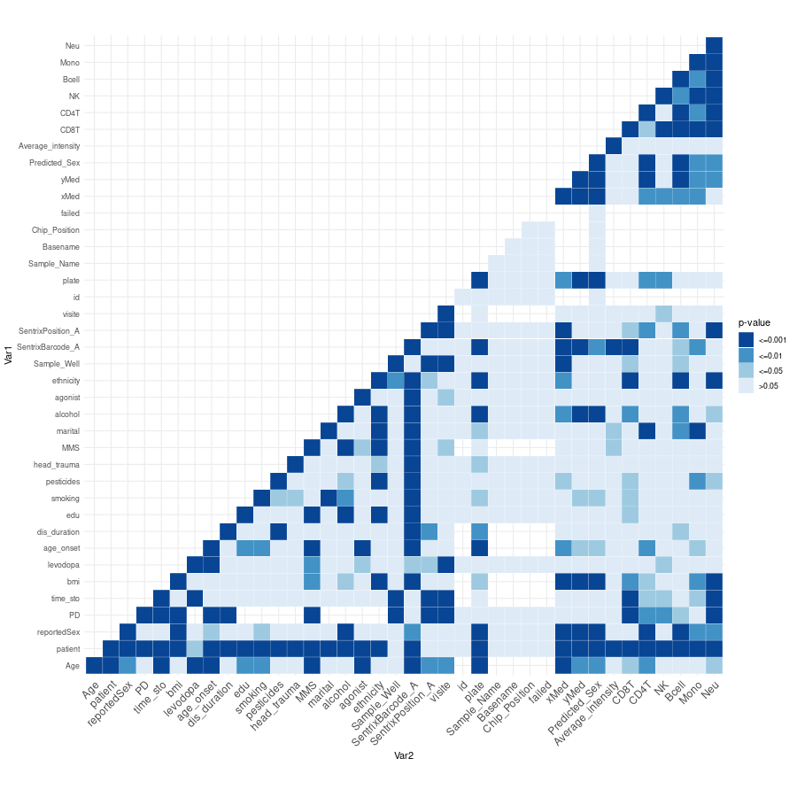

Meta data correlation in both sexes

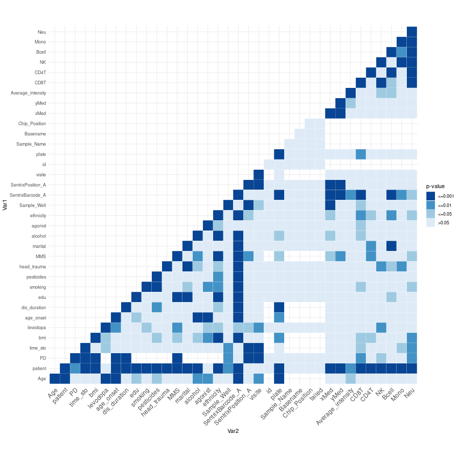

Meta data correlation in females

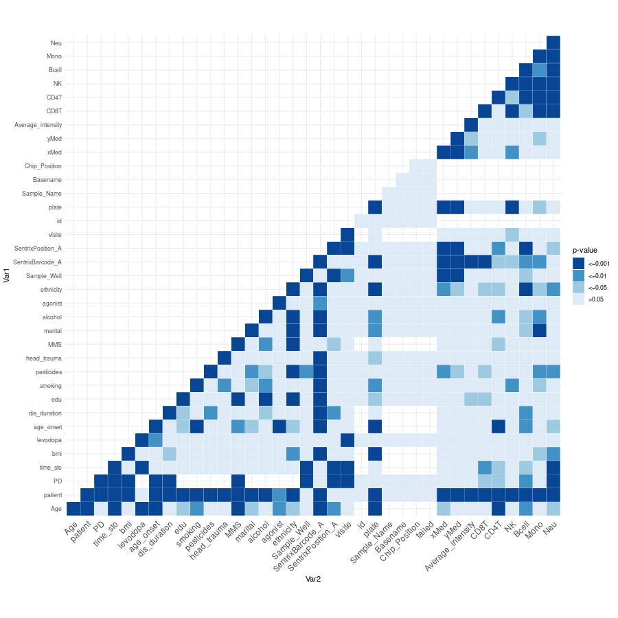

Meta data correlation in males

```r
#Create correlation matrix
digpd_meta <- digpd_meta[,-1]
digpd_meta <- digpd_meta[,-25]
digpd_meta_cor <- digpd_meta[,-32]
digpd_meta_cor <- digpd_meta_cor[,-32]
cormat <- correlation_pval(digpd_meta_cor)

# Get lower triangle of the correlation matrix
get_lower_tri<-function(cormat){
    cormat[upper.tri(cormat)] <- NA
    return(cormat)
  }
# Get upper triangle of the correlation matrix
get_upper_tri <- function(cormat){
    cormat[lower.tri(cormat)]<- NA
    return(cormat)
  }

upper_tri <- get_upper_tri(cormat)

#colour if sig
for(x in 1:nrow(upper_tri)){
  for(y in 1:ncol(upper_tri)){
    if(is.na(upper_tri[x,y])==FALSE){
    if(as.numeric(upper_tri[x,y])<=0.001){upper_tri[x,y]<-"<=0.001"}else{
    if(as.numeric(upper_tri[x,y])<=0.01){upper_tri[x,y]<-"<=0.01"}else{
      if(as.numeric(upper_tri[x,y])<=0.05){upper_tri[x,y]<-"<=0.05"}else{upper_tri[x,y]<-">0.05"}}}}
  }}
melted_cormat <- reshape2::melt(upper_tri, na.rm = TRUE)
png("~/preprocessing/DIGPD/082022/meta_cor_all_092022.png", width=900, height=900)
ggplot(data = melted_cormat, aes(Var2, Var1, fill = value))+
 geom_tile(color = "white")+
scale_fill_manual(values=c("#084594","#4292c6","#9ecae1","#deebf7"), name="p-value") +
  theme_minimal()+
 theme(axis.text.x = element_text(angle = 45, vjust = 1,
    size = 12, hjust = 1))+
 coord_fixed()
dev.off()

## females only
meta_F <- digpd_meta_cor[digpd_meta_cor$reportedSex=="F",-(c(3,31))]
cormat_F <- correlation_pval(meta_F)
upper_tri_F <- get_upper_tri(cormat_F)
for(x in 1:nrow(upper_tri_F)){
  for(y in 1:ncol(upper_tri_F)){
    if(is.na(upper_tri_F[x,y])==FALSE){
    if(as.numeric(upper_tri_F[x,y])<=0.001){upper_tri_F[x,y]<-"<=0.001"}else{
    if(as.numeric(upper_tri_F[x,y])<=0.01){upper_tri_F[x,y]<-"<=0.01"}else{
      if(as.numeric(upper_tri_F[x,y])<=0.05){upper_tri_F[x,y]<-"<=0.05"}else{upper_tri_F[x,y]<-">0.05"}}}}
  }}
melted_cormat_F <- reshape2::melt(upper_tri_F, na.rm = TRUE)
png("~/preprocessing/DIGPD/082022/meta_cor_F_092022.png", width=900, height=900)
ggplot(data = melted_cormat_F, aes(Var2, Var1, fill = value))+
 geom_tile(color = "white")+
scale_fill_manual(values=c("#084594","#4292c6","#9ecae1","#deebf7"), name="p-value") +
  theme_minimal()+
 theme(axis.text.x = element_text(angle = 45, vjust = 1,
    size = 12, hjust = 1))+
 coord_fixed()
dev.off()

## males only
meta_M <- digpd_meta_cor[digpd_meta_cor$reportedSex=="M",-(c(3,31))]
cormat_M <- correlation_pval(meta_M)
upper_tri_M <- get_upper_tri(cormat_M)
for(x in 1:nrow(upper_tri_M)){
  for(y in 1:ncol(upper_tri_M)){
    if(is.na(upper_tri_M[x,y])==FALSE){
    if(as.numeric(upper_tri_M[x,y])<=0.001){upper_tri_M[x,y]<-"<=0.001"}else{
    if(as.numeric(upper_tri_M[x,y])<=0.01){upper_tri_M[x,y]<-"<=0.01"}else{
      if(as.numeric(upper_tri_M[x,y])<=0.05){upper_tri_M[x,y]<-"<=0.05"}else{upper_tri_M[x,y]<-">0.05"}}}}
  }}
melted_cormat_M <- reshape2::melt(upper_tri_M, na.rm = TRUE)
png("~/preprocessing/DIGPD/082022/meta_cor_M_092022.png", width=900, height=900)
ggplot(data = melted_cormat_M, aes(Var2, Var1, fill = value))+
 geom_tile(color = "white")+
scale_fill_manual(values=c("#084594","#4292c6","#9ecae1","#deebf7"), name="p-value") +
  theme_minimal()+
 theme(axis.text.x = element_text(angle = 45, vjust = 1,
    size = 12, hjust = 1))+
 coord_fixed()
dev.off()
```

# Principal component analysis

Next I’ll use PCA to look at sources of variation in the data. This will also guide batch correction with ComBat. Code from Nicole Gladish.

## PCA on raw data

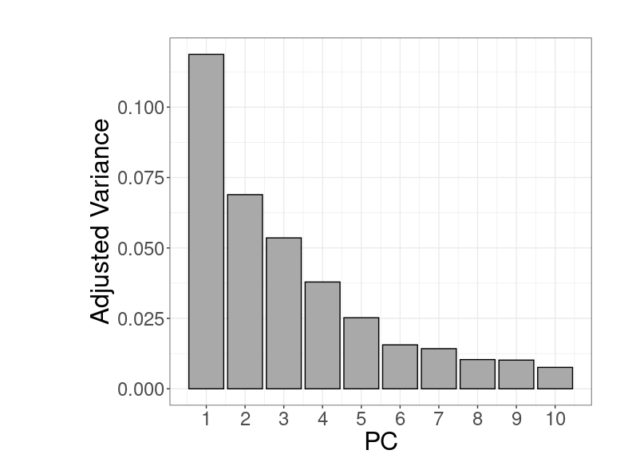

PCA on raw data - scree

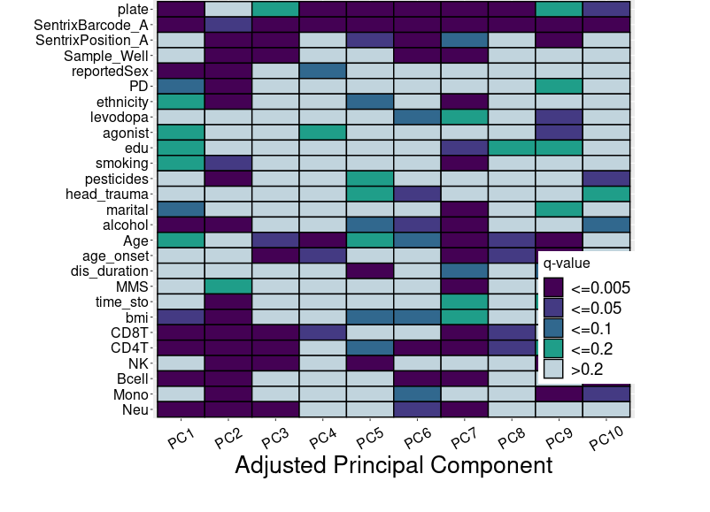

PCA on raw data - heat map

```r
# Here are the arguments you can add (and their defaults):
# PCA_Plot(PCA_Object, type = c("All", "Sparse"), nPCs = 10, MTC = F, Discrete = T, label.y_size = 12, label.x_size = 12, angle.x = 30, vjust.x = 0.5)
# Here is what some arguments do:
# type = c("All", "Sparse") - this is to tell it whether your PCA_Object results from a sparse or regular PCA (it does not do it for you it just tells the function what you have).
# nPCs - how many PCs do you want to plot
# MTC = F - do you want the associations multiple test corrected? BH is the method I include here
# Discrete = T, do you want a continuous display of significane values or discrete?

#restructing meta data and subsetting to categorical/continuous
nrow(digpd_meta <- digpd_meta[digpd_meta$Sample_Name %in% sampleNames(DIGPD_RG_Raw_noout),]) #425
digpd_meta <- digpd_meta[match(sampleNames(DIGPD_RG_Raw_noout), digpd_meta$Sample_Name),]
str(digpd_meta)
digpd_meta$levodopa <- as.factor(digpd_meta$levodopa)
digpd_meta$edu <- as.factor(digpd_meta$edu)
digpd_meta$reportedSex <- as.factor(digpd_meta$reportedSex)
digpd_meta$smoking <- as.factor(digpd_meta$smoking)
digpd_meta$pesticides <- as.factor(digpd_meta$pesticides)
digpd_meta$head_trauma <- as.factor(digpd_meta$head_trauma)
digpd_meta$PD <- as.factor(digpd_meta$PD)
digpd_meta$agonist <- as.factor(digpd_meta$agonist)
digpd_meta$SentrixBarcode_A <- as.factor(digpd_meta$SentrixBarcode_A)
digpd_meta$plate <- as.factor(digpd_meta$plate)
digpd_meta$alcohol <- as.factor(digpd_meta$alcohol)
digpd_meta$ethnicity <- as.factor(digpd_meta$ethnicity)
digpd_meta$marital <- as.factor(digpd_meta$marital)
rownames(digpd_meta) <- digpd_meta$Sample_Name

meta_categorical <- digpd_meta[,c("plate", "SentrixBarcode_A", "SentrixPosition_A", "Sample_Well", "reportedSex", "PD", "ethnicity", "levodopa", "agonist", "edu", "smoking", "pesticides", "head_trauma", "marital", "alcohol")]

meta_continuous <- digpd_meta[,c("Age", "age_onset", "dis_duration","MMS", "time_sto", "bmi","CD8T", "CD4T", "NK", "Bcell", "Mono", "Neu")]

#PCA on beta values: input
betas_raw <- getBeta(DIGPD_RG_Raw_noout)
all.equal(colnames(betas_raw), rownames(meta_categorical)) #TRUE
PCA_full<-princomp(betas_raw[complete.cases(betas_raw),])

ord <- c(seq(1:(ncol(meta_categorical)+ncol(meta_continuous))))
PCA_Plot(PCA_full, type="sparse", MTC=T, Discrete=T)
```